# Some practical computational aspects of non-parametric (distributional) regression

Ilaria Prosdocimi - Ca’ Foscari University of Venice

2023-03-06

## Preliminaries - data

We’ll make use of some dataset in the course of the session - mostly datasets avaiable in R packages, other than the data regarding the climate station at Hohenpeissenberg, in Germany, which is obtained from the DWD, the german climate office.

```r
climDat <- read.csv(file = "Hohenpeissenberg.csv", header = TRUE)
# climDat <- read.csv(file = "climateZug.csv", header = TRUE)
# with(climDat,plot(month,TMean))
# take yearly values
yclimDat <- aggregate(climDat[,c("Precip","TMean","year")], by = list(climDat$year),FUN = mean, na.rm = TRUE)[,c("Precip","TMean","year")]
yclimDat$sYear <- (yclimDat$year-min(yclimDat$year))/diff(range(yclimDat$year))
yclimDat <- na.omit(yclimDat)
```

We will also use the following dataset:

```r
data("airquality", package = "datasets")
data("mcycle", package = "MASS")
# this one might require you to install the package
data("ethanol", package = "SemiPar")
# or load the data save in the repo manually
# write.table(ethanol, "ethanol.csv",sep=",",quote = FALSE)
```

## Refernces and inspirations

Key introduction books:

Wood, Simon N. (2017) Generalized Additive Models: An Introduction with R, CRC, 2nd edition

Eilers, P.H.C. and Marx, B.D. (2021). Practical Smoothing, The Joys of P-splines. Cambridge University Press. ([book website](https://psplines.bitbucket.io))

Harezlak, J., Ruppert, D. and Wand, M.P., 2018. Semiparametric regression with R. New York: Springer.

This latter book is the “follow-up” of

Ruppert, D., Wand, M.P. and Carroll, R.J., 2003. Semiparametric regression. Cambridge university press.

Some slightly different philosophies to non-/semi-parametric regression presented in these books: they are all similar but there are some differences in the estimation approaches.

The first original reference for Generalized Additive Models is

Hastie, T. and Tibshirani, R., 1987. Generalized additive models: some applications. Journal of the American Statistical Association, 82(398), pp.371-386.

which resulted in the book

Hastie, T. and Tibshirani, R., 1990. Generalized additive models: some applications. CRC Press

but the Hastie and Tibshirani book/approach has been somewhat superseded (even if it is still valid, useful and relevant).

Key references on distributional regression/Structured Additive Regression (STAR) Models are:

Stasinopoulos et al (2017), Flexible Regression and Smoothing: Using GAMLSS in R, CRC

Fahrmeir L, Kneib T, Lang S, Marx B (2013). Regression – Models, Methods and Applications. Springer-Verlag, Berlin.

An additional useful reference is:

Thomas W. Yee (2015). Vector Generalized Linear and Additive Models: With an Implementation in R. New York, USA: Springer.

The journal Statistical Modelling published a [special issue](https://journals.sagepub.com/toc/smja/18/3-4) on the topic of flexible models for extending the classical (generalized) linear model framework with very practical tutorials on a number of extensions: most of these papers are very accessible and well written by leading experts on the topic.

Today I will focus on some practical aspects of how these models are estimated in practice, which hopefully will help in understanding how they work.

## Why bother?

The linear/polynomial model sometime is not flexible enough to model data which have particular features:

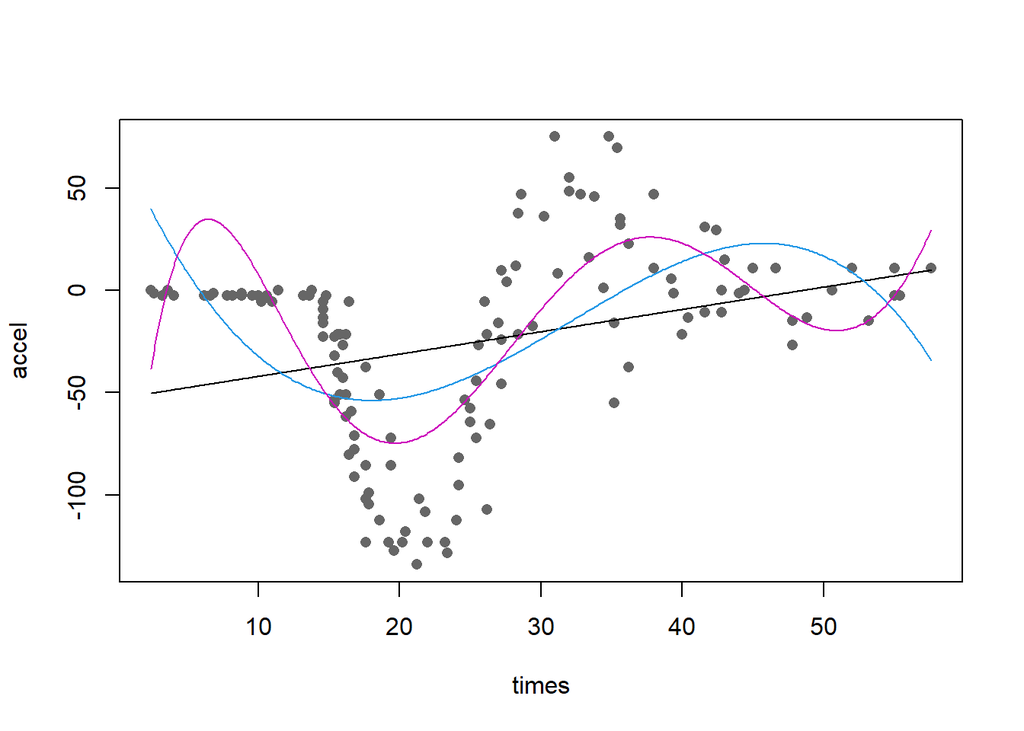

```r
data(mcycle, package = "MASS")
# help(mcycle, package = "MASS")
plot(mcycle, pch = 16, col = "grey40")
nd <- data.frame(times = seq(2.4,57.6,by=0.1))
lines(nd$times, predict(lm(accel ~ times, data = mcycle), newdata = nd))
# doesn't cut it
lines(nd$times, predict(lm(accel ~ poly(times,4), data = mcycle), newdata = nd), col = 4)
# not complex enough
lines(nd$times, predict(lm(accel ~ poly(times,6), data = mcycle), newdata = nd), col = 6)
```

```r
rm(nd)
```

The fit is not particularity good and it is too wiggly in many parts of the domain.

Furthermore polynomial regression is “global”:

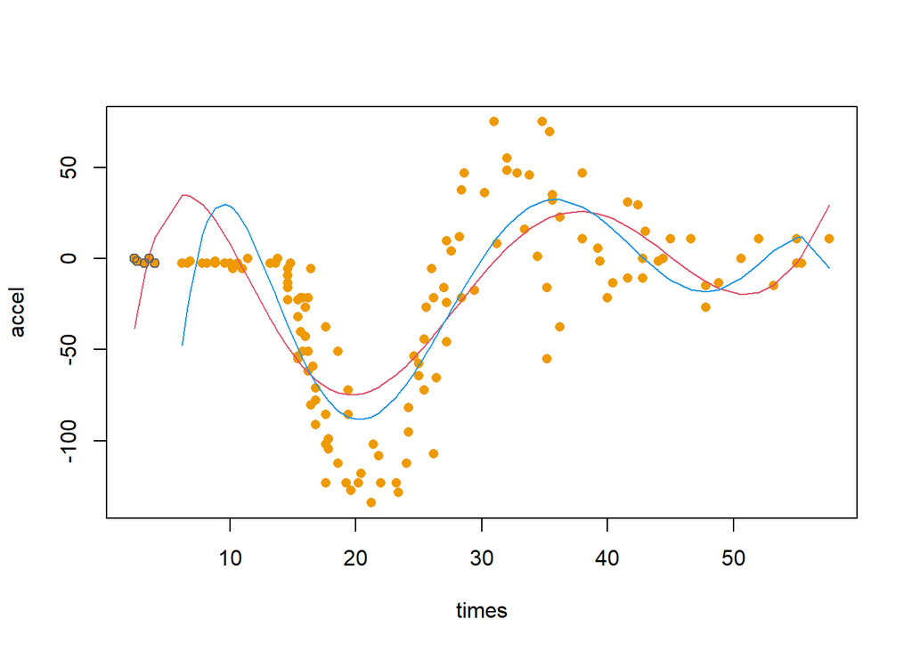

```r
plot(mcycle, pch = 16, col = "orange2")
with(mcycle,lines(times, predict(lm(accel ~ poly(times,6))), col = 2, lwd = 1.4))
# differences are visible also at locations for high "times"
with(mcycle[mcycle$times <5,],points(accel ~ times, col = "grey40"))
with(mcycle[mcycle$times >5,],lines(times, predict(lm(accel ~ poly(times,6))), col = 4, lwd = 1.4))
```

Not including a tiny amount of the sample with low $x$ values changes the fit for the whole function, even for high $x$ values.

Even a piece-wise linear model can be not really flexible enough (and would not allow for a continuous derivative). We therefore need to find a way to obtain some smooth fit, which is flexible as the polynomial fit can be but less impacted by the global behavior of polynomials.

Exercise 2 of Chapter 4 in Wood’s book gives an illuminating example about the local/global issue and how some local splines can overcome the problem (code slightly modified). We generate some noisy smooth data, try to fit them with polynomial fits and compare the interpolation properties of the polynomial fit with that obtained from a (regression) cubic spline basis of the shape:
$$b_1(x) =
1, \ b_2(x) = x, \ b_{j+2}(x) = |x - x^*_j|^3, \text{ for } j= 1,
\ldots, q-2$$
where $q$ is the basis dimension and $x^*_j$ are the knots locations (we’ll talk more about this later). We’ll take $q = 11$ and equally spaced knots over the range of $x$ values:

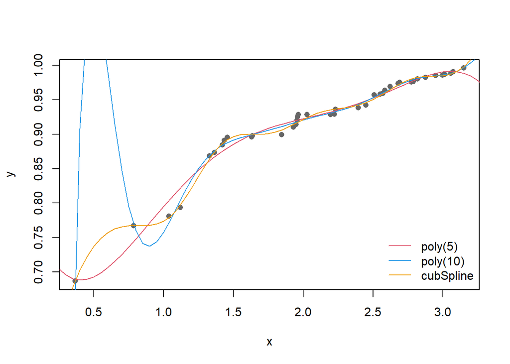

```r
# generate some noisy smooth data
set.seed(1)
n <- 40
x <-sort(runif(n)*10)^.5
y <-sort(runif(n))^.1
plot(x,y, pch = 16, col = "grey40")
# estimate polynomial models and then use the model fit to interpolate
nd <- data.frame(x = seq(0,4,by=0.05))
lines(nd$x, predict(lm(y ~ poly(x,5)), newdata = nd), col = 2)
lines(nd$x, predict(lm(y ~ poly(x,10)), newdata = nd), col = 4) # ups
# define some cubic splines over knots
cubSpline <- function(x, knots=NULL){
  X <- cbind(rep(1,length(x)), x)
  for(j in seq_along(knots)) X <- cbind(X, (abs(x-knots[j]))^3)
  X
}
# define the knots
xknots <-  seq(min(x),max(x), length.out = 9) # equally spaced
lines(nd$x, cubSpline(nd$x, knots =  xknots) %*% coef(lm(y ~ cubSpline(x, knots =  xknots)-1)), col = "orange2")
legend("bottomright",bty = "n", col = c(2,4,"orange2"), legend = c("poly(5)","poly(10)","cubSpline"), lwd = 1.3)
```

```r
rm(x,y,n,nd,xknots)
```

The fit obtained with the spline is flexible enough to capture the smooth relationship and does not have issues when interpolating in data sparse regions - let’s see what would happen to the `mcycle` data:

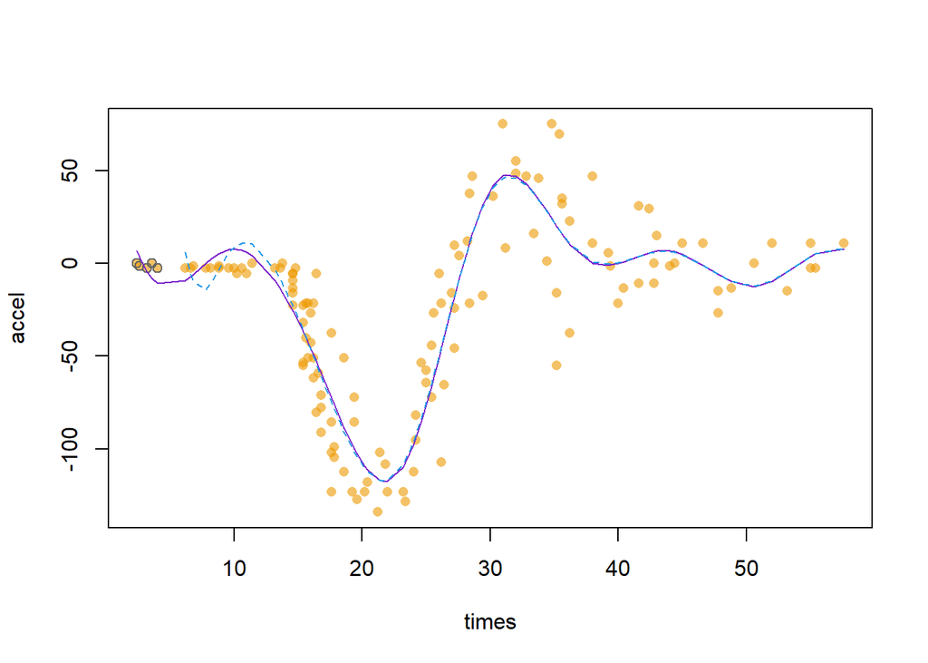

```r
# defined the knots
xknots <-  seq(min(mcycle$times),max(mcycle$times), length.out = 9) # equally spaced
plot(mcycle, pch = 16, col = rgb(0.93,0.60,0,0.6))
with(mcycle[mcycle$times <5,],points(accel ~ times, col = "grey40"))
with(mcycle,lines(times, predict(lm(accel ~ cubSpline(times,xknots)-1)), col = "purple3", lwd = 1.3))
# basically same fit for areas which are in both training sets
with(mcycle[mcycle$times >5,],lines(times, predict(lm(accel ~ cubSpline(times,xknots)-1)), col = 4, lwd = 1.3, lty = 2))
```

Notice this is achieved using `lm`, we are simply fitting the usual linear model but using a custom-defined $\boldsymbol{X}$ matrix. So, how is the nice local behavior of the spline-based fit achieved?

Let’s look closely at the basis function:

$$\text{Polynomial basis:} \ b_1(x) = 1, \
b_2(x) = x, \ b_3(x) = x^2 \ b_{j}(x) = x^{j-1}, \text{ for } j= 1,
\ldots, d$$

$$\text{Cubic spline basis:} \ b_1(x) = 1,
\ b_2(x) = x, \ b_{j+2}(x) = |x - x^*_j|^3, \text{ for } j= 1, \ldots,
q-2$$

Let’s plot the different columns of $\boldsymbol{X}$:

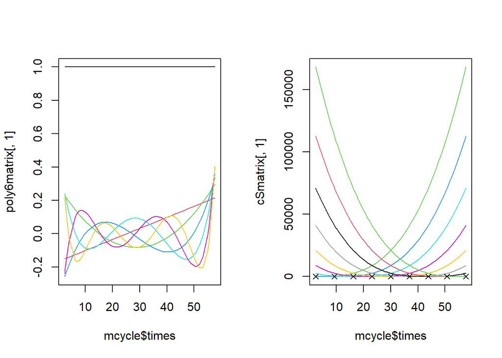

```r
par(mfrow = c(1,2))
# polynomial matrix d = 6
poly6matrix <- with(mcycle, model.matrix(accel ~ poly(times,6)))
# cubic spline
cSmatrix <- with(mcycle, model.matrix(accel ~ cubSpline(times,xknots)-1))
plot(mcycle$times,poly6matrix[,1], type = "l", ylim = range(poly6matrix))
for(j in 2:ncol(poly6matrix)) lines(mcycle$times,poly6matrix[,j],col = j)
plot(mcycle$times,cSmatrix[,1], type = "l", ylim = range(cSmatrix)) #, ylim = c(-0.6,15))
for(j in 2:ncol(cSmatrix)) lines(mcycle$times,cSmatrix[,j],col = j)
points(xknots,rep(-.1,9),pch = 4)
```

```r
rm(xknots,cSmatrix,j,poly6matrix)
```

The cubic basis are more local depending on the knot to which the refer to. This is similar to what happens when using loess or kernel methods: local fits are not affected by what happens in other parts of the sample. The advantage (one of) of smoothing by splines is the relative ease of estimation, since we can exploit routines developed for (penalized) regression since all we are doing is using a specific basis as our design matrix. There are several possible choices of basis functions, the choice of which spline to use in GAM fitting can be quite important, especially when combined with the second element of GAMS: the penalty. We’ll walk trough this using even simpler basis functions (the presentation of the material follows chapter 4 of Wood, 2017).

## Univariate Smoothers

Let’s start with a much simpler basis function than the cubic splines seen in action above and use a piecewise linear basis. We need to define a set of *knots* $(x^*_1, \ldots, x^*_k)$ (with $x^*_{j} > x^*_{j-1}$), i.e. the points at which the piece-wise linear pieces will join and that are the location of the function discontinuities. Then for $j = 2, \ldots, k-1$ we have

$$b_j(x) = \begin{cases}
\frac{x-x^*_{j-1}}{x^*_{j}-x^*_{j-1}} & x^*_{j-1} < x <
x^*_{j} \\
\frac{x^*_{j+1}-x}{x^*_{j+1}-x^*_{j}} & x^*_{j} < x <
x^*_{j+1} \\
0 & \text{otherwise} \\
\end{cases}$$

and for $j=1$ and $j=k$ we take

$$b_1(x) = \begin{cases}
\frac{x^*_{2}-x}{x^*_{2}-x^*_{1}} & x < x^*_{2} \\
0 & \text{otherwise} \\
\end{cases} \qquad b_k(x) = \begin{cases}
\frac{x-x^*_{k-1}}{x^*_{k}-x^*_{k-1}} & x > x^*_{k-1} \\
0 & \text{otherwise} \\
\end{cases}$$

This definition produces what is termed the *tent functions*, since they take value of 0 everywhere except between $(x^*_{j-1},x^*_{j+1})$: from $x^*_{j-1}$ they grow linearly, reach a peak value of 1 at $x^*_{j}$ and then decrease linearly till $x^*_{j+1}$. They can also be thought of the linear interpolator of the data ${x^*_{i}, \delta^j_i : i = 1, \ldots, k}$, where $\delta^j_i = 1$ if $i=j$ and 0 otherwise. Let’s build it in R:

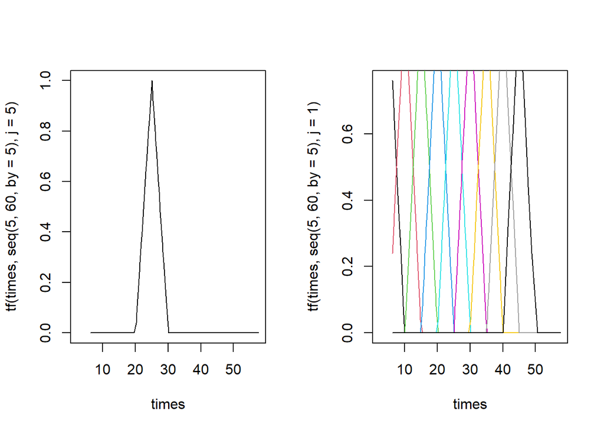

```r
# for a set of knots, build the jth basis
tf <- function(x, knots, j){
  deltai <- rep(0, length(knots)); deltai[j] <- 1
  approx(x = knots, y = deltai, xout = x)$y
}
par(mfrow=c(1,2))
# one tent function
with(mcycle,plot(times, tf(times, seq(5,60,by=5),j=5), type = "l"))
#  the whole basis
with(mcycle,plot(times, tf(times, seq(5,60,by=5),j=1), type = "l"))
for(j in 2:9) with(mcycle,lines(times, tf(times, seq(5,60,by=5),j=j), col = j, type = "l"))
```

We can use this to construct a design matrix $\boldsymbol{X}$ to use for smoothing:

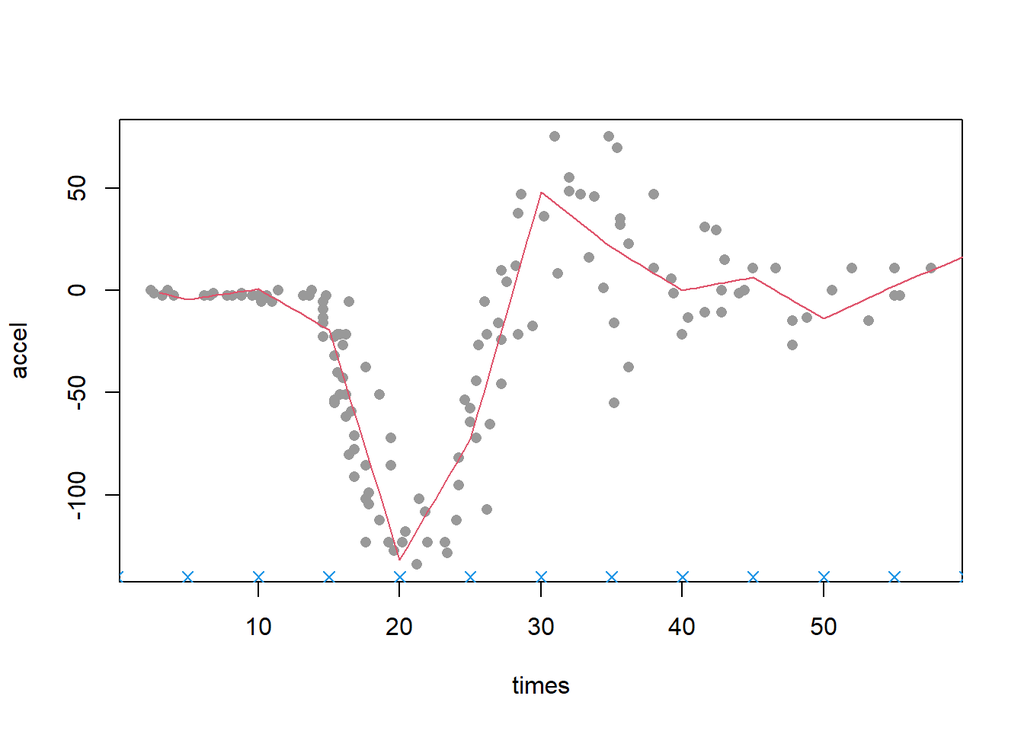

```r
tf.X <- function(x,knots){
  nk <- length(knots); n <- length(x)
  X <- matrix(NA, nrow = n, ncol = nk)
  for(j in 1:nk) X[,j] <- tf(x, knots, j=j)
  X
}
Xtf_mcycle <- tf.X(mcycle$times, knots = seq(0,60,by=5))
fittf_mcycle <- lm(mcycle$accel ~ Xtf_mcycle-1)
plot(mcycle, pch = 16, col = "grey60")
valX <- tf.X(seq(3,60,by=0.5), knots = seq(0,60,by=5))
lines(seq(3,60,by=0.5), valX %*% coef(fittf_mcycle), col = 2)
points(seq(0,60,by=5), rep(-140,13),col=4,pch=4)
```

```r
rm(Xtf_mcycle,fittf_mcycle,valX)
```

The fitted line captures the overall behavior of the data, but the number of knots (and consequently the possible complexity of the shape of the function/ the number of estimated parameters) was fixed arbitrarily. We could think of using some model selection approach, but the implementation of this could be cumbersome, so we prefer to use a largish number of knots/basis dimension and to control the model smoothness via a penalty that controls the wiggliness of the fitted function. For example we could measure the fitted function’s wiggliness as the squared second difference of the function at the knots:
$$w_j =
(f(x^*_{j+1})-f(x^*_{j})-(f(x^*_{j})-f(x^*_{j-1})))^2 = (f(x^*_{j+1})-2
f(x^*_{j})-f(x^*_{j-1}))^2$$
This is a crude approximation of the second derivative penalty used in (cubic) spline smoothing (taking equally spaced knots).

We wish to obtain a fitted function such that it is not too wiggly, which corresponds to constraining the optimization with the constraint that $\sum_{j=2}^{k-1}w_j < C$, where $C$ is a fixed constant which controls the wiggliness of the function: large values of $C$ would correspond to wiggly curves.

Using the Lagrangian approach to optimization under constraints we therefore find that the we wish to minimize the following quantity:
$$||\boldsymbol{y} - \boldsymbol{X}
\boldsymbol{\beta}||^2 + \lambda \sum_{j=1}^{k-1}w_j$$
(notice that the wiggliness is evaluated for $k-2$ points).

Finally, for the tent function we notice that $f(x^*_j) = \beta_j$, so we can write: $w_j = (\beta_{j-1} - 2 \beta_j +\beta_{j+1})$, which we need to evaluate for $j=2, \ldots, k-1$. This makes it possible to write the penalty term in matrix form, since:

$$\begin{bmatrix}
\beta_1 - 2 \beta_2 + \beta_3 \\
\beta_2 - 2 \beta_3 + \beta_4 \\
\vdots \\
\beta_{k-2} - 2 \beta_{k-1} + \beta_k \\
\end{bmatrix} = \begin{bmatrix}
1 & - 2 & 1 & \cdots & \cdots & \cdots \\
0 & 1 & - 2 & 1 & \cdots & \cdots \\
\vdots & \vdots & \vdots & \vdots & \vdots
& \vdots \\
\cdots & \cdots & \cdots & 1 & - 2 & 1
\end{bmatrix} \boldsymbol{\beta} = \boldsymbol{D}
\boldsymbol{\beta}$$

and we can write

$$\sum_{j=1}^{k-1} w_j =
\boldsymbol{\beta}^\top \boldsymbol{D}^\top \boldsymbol{D}
\boldsymbol{\beta}$$
and taking $\boldsymbol{S} = \boldsymbol{D}^\top \boldsymbol{D}$ we rewrite the optimization problem as:

$$||\boldsymbol{y} - \boldsymbol{X}
\boldsymbol{\beta}||^2 + \lambda \boldsymbol{\beta}^\top \boldsymbol{S}
\boldsymbol{\beta}$$

which, for a fixed value of $\lambda$, leads to

$$\hat{\boldsymbol{\beta}} =
\left(\boldsymbol{X}^T \boldsymbol{X} + \lambda \boldsymbol{S}
\right)^{-1} \boldsymbol{X}^T \boldsymbol{y}$$

hence we find that the hat matrix such that $\hat{\boldsymbol{f}} = \boldsymbol{A} \boldsymbol{y}$ is $\boldsymbol{A} = \boldsymbol{X} \hat{\boldsymbol{\beta}} = \left(\boldsymbol{X}^T \boldsymbol{X} + \lambda \boldsymbol{S} \right)^{-1} \boldsymbol{X}^T$.

Penalized regression splines thus lead to a linear smoother and we can derive the equivalent kernel for each observation $i$ as the $i^\text{th}$ row of the hat matrix.

Let’s see the effect of $\lambda$ in practice. First we need to construct $\boldsymbol{S} = \boldsymbol{D}^\top \boldsymbol{D}$, which we can create using `diff`:

```r
## an example
diff(diag(5), differences = 2)
```

```
##      [,1] [,2] [,3] [,4] [,5]
## [1,]    1   -2    1    0    0
## [2,]    0    1   -2    1    0
## [3,]    0    0    1   -2    1
```

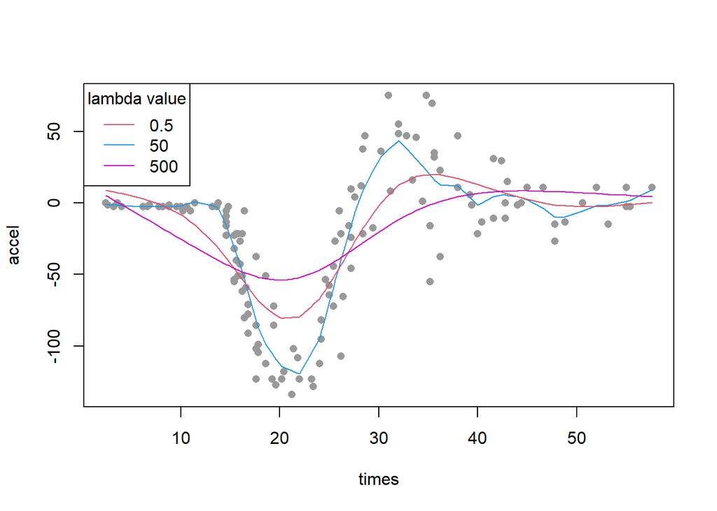

```r
# the design matrix
Xtf_mcycle <- tf.X(mcycle$times, knots = seq(0,60,by=2))
# let's create S
S <- t(diff(diag(ncol(Xtf_mcycle)), differences = 2)) %*% diff(diag(ncol(Xtf_mcycle)), differences = 2)
## this is not the best way to compute this
hatf_05 <- Xtf_mcycle %*% solve(crossprod(Xtf_mcycle)+.5*S) %*% t(Xtf_mcycle) %*% mcycle$accel
hatf_50 <- Xtf_mcycle %*% solve(crossprod(Xtf_mcycle)+50*S) %*% t(Xtf_mcycle) %*% mcycle$accel
hatf_500 <- Xtf_mcycle %*% solve(crossprod(Xtf_mcycle)+500*S) %*% t(Xtf_mcycle) %*% mcycle$accel
plot(mcycle, pch = 16, col = "grey60")
lines(mcycle$times, hatf_05, col = 4)
lines(mcycle$times, hatf_50, col = 2)
lines(mcycle$times, hatf_500, col = 6)
legend("topleft",col = c(2,4,6), legend = c(.5,50,500),title = "lambda value",lwd=1.4)
```

Let’s look at the equivalent kernels:

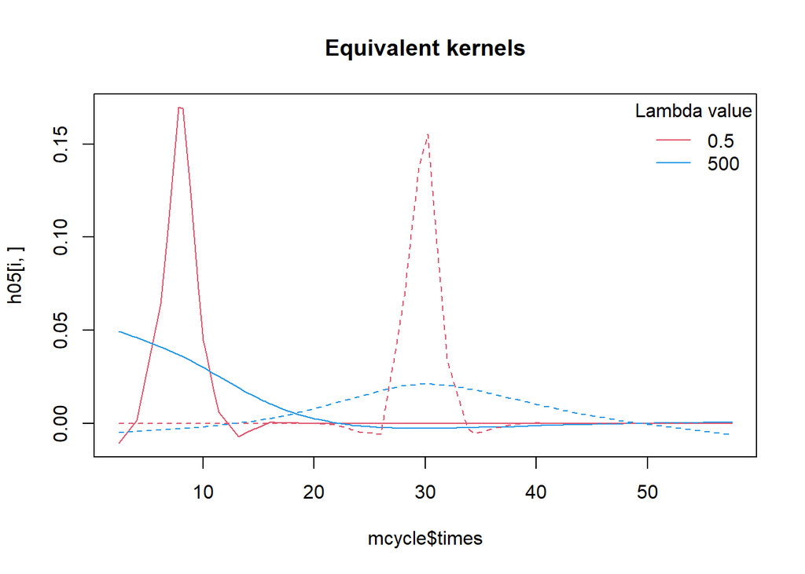

```r
h05 <- Xtf_mcycle %*% solve(crossprod(Xtf_mcycle)+.5*S) %*% t(Xtf_mcycle)
h500 <- Xtf_mcycle %*% solve(crossprod(Xtf_mcycle)+500*S) %*% t(Xtf_mcycle)
par(mfrow=c(1,1))
i = 10; plot(mcycle$times, h05[i,], col = 2, type = "l"); lines(mcycle$times, h500[i,], col = 4)
i = 90; lines(mcycle$times, h05[i,], col = 2, lty = 2, type = "l"); lines(mcycle$times, h500[i,], col = 4, lty = 2)
title(main = "Equivalent kernels")
legend("topright", bty ="n",col=c(2,4),lwd = 1,legend = c("0.5","500"), title = "Lambda value")
```

A more computationally stable way of obtaining the penalized least square fit is to exploit the fact that:

$$||\boldsymbol{y} - \boldsymbol{X}
\boldsymbol{\beta}||^2 + \lambda \boldsymbol{\beta}^\top \boldsymbol{S}
\boldsymbol{\beta} = \left\Vert \begin{bmatrix} \boldsymbol{y} \\
\boldsymbol{0} \end{bmatrix} - \begin{bmatrix} \boldsymbol{X} \\
\sqrt{\lambda} D \end{bmatrix} \boldsymbol{\beta}
\right\Vert^2$$

so

```r
X500augment <- rbind(Xtf_mcycle, sqrt(500) * diff(diag(ncol(Xtf_mcycle)), differences = 2))
yaugment <- c(mcycle$accel, rep(0, ncol(Xtf_mcycle)-2))
althatf_500 <- fitted(lm(yaugment ~ X500augment-1))
hatf_500 <- Xtf_mcycle %*% solve(crossprod(Xtf_mcycle)+500*S) %*% t(Xtf_mcycle) %*% mcycle$accel
head(althatf_500)
```

```
##          1          2          3          4          5          6
##  5.2251399  4.4256041  2.0269969  0.4279254 -1.1711461 -9.9939607
```

```r
head(hatf_500[,1])
```

```
## [1]  5.2251399  4.4256041  2.0269969  0.4279254 -1.1711461 -9.9939607
```

since under the hood R uses an optimized $\boldsymbol{Q} \boldsymbol{R}$ decomposition for fitting linear models this procedure is more computationally stable (and in general using the $\boldsymbol{Q} \boldsymbol{R}$ decomposition for an augmented model is a good way to practically estimate $\boldsymbol{\beta}$ for a given $\lambda$).

We can indeed write a generic function to construct penalized regression estimates:

```r
preg.fit <- function(y,x,knots,spar){
  X<-tf.X(x, knots = knots) # design matrix
  D <- diff(diag(length(knots)),differences = 2)
  Xaug <- rbind(X, sqrt(spar) * D)
  yaugment <- c(y, rep(0, nrow(D)))
  lm(yaugment ~ Xaug-1)
}
head(fitted(preg.fit(y = mcycle$accel, x = mcycle$times, knots = seq(0,60,by=2), spar = 100)))
```

```
##         1         2         3         4         5         6
## 13.133089 12.525953 10.704544  9.490272  8.275999  1.207337
```

### Smoothing as Regularization

**penalized regression is regularized regression**

Note that the form of the estimation of $\boldsymbol{\beta}$ for a given $\lambda$ has a very similar form of the estimated coefficients one would obtain when applying *ridge regression*, which is employed as a form of *regularization* is regression problems in which either $p>n$ or in which there are issues of multi-collinearity in the predictors. In these situations one typically can not solve the system of equations required to obtain the least square estimate (and in practical terms one can not obtain $(\boldsymbol{X}^\top \boldsymbol{X})^{-1}$). Ridge regression overcomes this issue by placing a particular form of constraints on the parameters, which result in $\hat{\boldsymbol{\beta}}^{Ridge}$ to be chosen to minimize:

$$||\boldsymbol{y} - \boldsymbol{X}
\boldsymbol{\beta}||^2 + \lambda \boldsymbol{\beta}^\top
\boldsymbol{\beta} = \sum_{i=1}^{n} (y_i - \sum_{j=1}^{p}
x_{ij}\beta_j)^2+\lambda \sum_{j=1}^{p} \beta_j^2$$

The penalty term results from constraining the sum of the squares of the regression coefficients to be smaller than a certain constant $C$: $\sum_{j=1}^{p} \beta^2_j \leq C$.

We find that: $\hat{\boldsymbol{\beta}}^{Ridge} = (\boldsymbol{X}^\top \boldsymbol{X} + \lambda \boldsymbol{I})^{-1}\boldsymbol{X}^\top \boldsymbol{y}$ and taking $\boldsymbol{R} = (\boldsymbol{X}^\top \boldsymbol{X})^{-1}$ we have that:

$$\hat{\boldsymbol{\beta}}^{Ridge} =
(\boldsymbol{I} + \lambda
\boldsymbol{R})^{-1}\hat{\boldsymbol{\beta}}^{LS}$$

This shows that Ridge Regression (and in general penalized approaches) is biased (remember that $\hat{\boldsymbol{\beta}}^{LS}$ is unbiased) and that the least square estimate is retrieved when $\lambda = 0$, i.e. when no penalization is applied. Interestingly though the variance of $\hat{\boldsymbol{\beta}}^{Ridge}$ is found to be typically smaller than that of $\hat{\boldsymbol{\beta}}^{LS}$, and therefore ridge regression can be found to have smaller RMSE for finite samples.

Let’s see ridge regression in action:

```r
set.seed(441)
n <- 6; p <- 10; # p > n
X <- scale(matrix(runif(n*p,0,1),ncol = p))
y <- rnorm(n,X %*% rnorm(p,0,2)); y <- y - mean(y)
f_orig <- lm(y~X-1); coef(f_orig)
```

```
##         X1         X2         X3         X4         X5         X6         X7
## -1.9717134  0.8087821 -4.8193283  1.9709263 -0.3900684         NA         NA
##         X8         X9        X10
##         NA         NA         NA
```

```r
f_ridge <- MASS::lm.ridge(y~X-1, lambda = 5); coef(f_ridge)
```

```
##          X1          X2          X3          X4          X5          X6
## -0.47312719  0.95484787 -1.14975690 -0.06270916  0.63622452  1.04517271
##          X7          X8          X9         X10
## -0.69946007  0.15308814 -0.62772990 -0.39432273
```

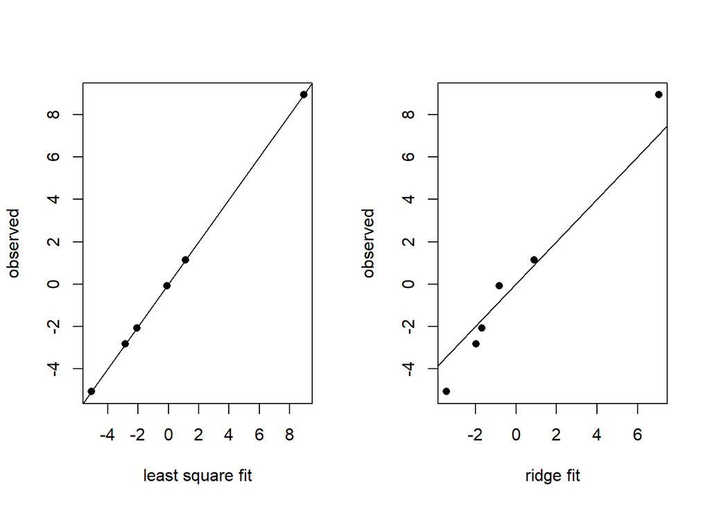

```r
par(mfrow=c(1,2),pch=16)
plot(fitted(f_orig), y, xlab = "least square fit", ylab = "observed"); abline(0,1)
plot(X %*% coef(f_ridge), y, xlab = "ridge fit", ylab = "observed"); abline(0,1)
```

```r
rm(n,X,y,p,f_orig,f_ridge)
```

Notice that Ridge Regression is also known under the name of Tikhonov regularization, and it is widely employed in the inverse problems literature (sometimes wheels are re-invented many times).

Another very famous form of regularization in regression models is the least absolute shrinkage and selection operator (lasso), which is derived when performing linear regression under the constraint: $\sum_{j=1}^{k} |\beta_j| < C$, which leads to estimates found by minimizing:

$$\sum_{i=1}^{n} (y_i - \sum_{j=1}^{p}
x_{ij}\beta_j)^2+\lambda \sum_{j=1}^{p} |\beta_j|$$

Due to the difference in the constraints under which the model parameters are derived ridge regression and lasso are often also identified as L2 and L1 regularized regression.

The key point for our purpose is to realize that smoothing by means of penalized regression splines is “nothing but” a regularized regression.

### Smoothing parameter choice

We now get to the tricky part of penalized regression splines (and regularized regression in general): choosing $\lambda$. There isn’t a “best” way to choose $\lambda$, but there are some sensible metrics which can be used, such as cross-validation (CV), a generalized form of cross-validation (GCV), AIC and other likelihood and bayesian metrics which we don’t discuss today.

We could think to a suitable way to choose $\lambda$ would be to find the value such that the fitted values are as close as possible to the observed vales, i.e. to minimize:
$$M = \frac{1}{n}\sum_{i=1}^{n} (\hat{m}_i -
m_i)^2$$
where $\hat{m}_i \equiv \hat{m}(x_i)$, $m_i \equiv m(x_i)$. Since $f(x)$ is unknown we can not compute $M$ but we can derive an estimate of it using the ordinary cross validation score defined as:
$$\mathcal{V}_o =
\frac{1}{n}\sum_{i=1}^{n} (\hat{m}^{[-i]} - y_i)^2$$
where $\hat{m}^{[-i]}$ is a fitted model derived when the observation $y_i$ is not included in the model. It can be shown that it is not actually necessary to hold-out the $i$th observation and iterate the estimation procedure $n$ times as we can derive that
$$\mathcal{V}_o =
\frac{1}{n}\sum_{i=1}^{n} (y_i -
\hat{m}_{i})^2/(1-\boldsymbol{A}_{ii})^2$$
where $A$ is the hat matrix of the model (which in the penalized regression spline case depends on $\lambda$). This simplification of the OCV which avoids needing to effectively hold-out the $i$th observation is only valid for the gaussian case. Let’s see how $\mathcal{V}_o$ changes as a function of $\lambda$ using the `mcycle` data (and the same large number of knots used before):

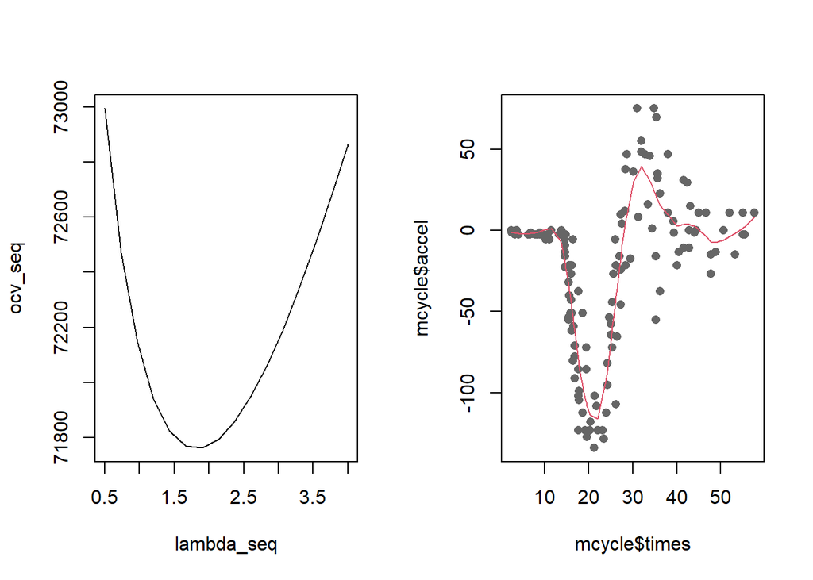

```r
ocv <- function(lambda, y, x,knots){
  n <- length(y)
  modelFit <- preg.fit(y = y, x = x, knots = knots, spar = lambda)
  fval <- fitted(modelFit)[1:n]
  hatValues <- hatvalues(modelFit)[1:n]
  sum(((y-fval)/(1-hatValues))^2)
}
lambda_seq <- seq(.5,4,length.out = 16)
ocv_seq <- rep(NA, length(lambda_seq))
for(j in seq_along(lambda_seq)) ocv_seq[j] <- ocv(lambda_seq[j],y = mcycle$accel, x = mcycle$times, knots = seq(0,60,by=2))
par(mfrow = c(1,2), pch = 16)
plot(lambda_seq, ocv_seq, type="l")
plot(mcycle$times, mcycle$accel, col = "grey40")
lines(mcycle$times, fitted(preg.fit(y =  mcycle$accel, x = mcycle$times, knots = seq(0,60,by=2), spar = lambda_seq[which.min(ocv_seq)]))[1:nrow(mcycle)], col=2, lwd = 1.4)
```

```r
rm(lambda_seq, ocv_seq)
```

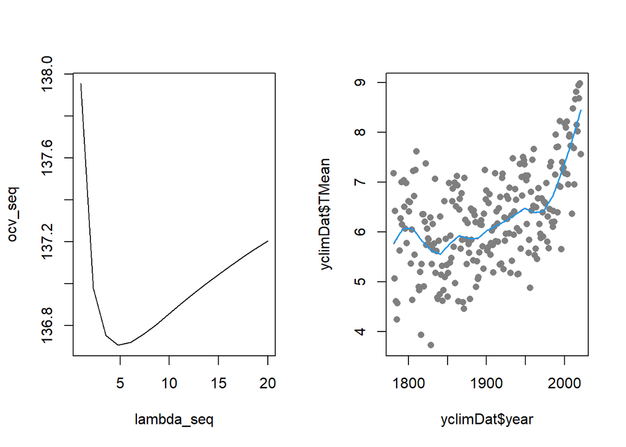

```r
lambda_seq <- seq(1,20,length.out = 16)
ocv_seq <- rep(NA, length(lambda_seq))
for(j in seq_along(lambda_seq)) ocv_seq[j] <- ocv(lambda_seq[j],y = yclimDat$TMean, x = yclimDat$sYear, knots = seq(0,1,by=.05))
par(mfrow = c(1,2), pch = 16)
plot(lambda_seq, ocv_seq, type="l")
plot(yclimDat$year, yclimDat$TMean,col="grey50")
lines(yclimDat$year, fitted(preg.fit(y = yclimDat$TMean, x = yclimDat$sYear, knots = seq(0,1,by=.05), spar = lambda_seq[which.min(ocv_seq)]))[1:nrow(yclimDat)], col=2, lwd = 1.6)
# numerical optimization of OCV
ocv_opt <- optimise(ocv,y = yclimDat$TMean, x = yclimDat$sYear, knots = seq(0,1,by=.05), interval = c(0,500))
lines(yclimDat$year, fitted(preg.fit(y = yclimDat$TMean, x = yclimDat$sYear, knots = seq(0,1,by=.05), spar = ocv_opt$minimum))[1:nrow(yclimDat)], col = 4, lwd = 1.6)
```

```r
rm(lambda_seq, ocv_seq)
```

Each observation in the dataset contributes to the computation of $\mathcal{V}_o$ with the model residual with a wight which depends on the hat value of the observation, i.e. a measure of how influential each observation will be. When highly influential observations are present in the data, these will be given a much higher weight, which intuitively might be a bad idea. For this and other reasons, a modification of the OCV is proposed, the so-called, Generalized Cross Validation (GCV), in which each element $\boldsymbol{A}_{ii}$ is replaced by $tr(\boldsymbol{A})/n$. We therefore define:
$$\mathcal{V}_g =
\frac{1}{n} \sum_{i=1}^{n} \frac{(y_i -
\hat{m}_{i})^2}{(1-tr(\boldsymbol{A})/n)^2}$$

Let’s see it in action:

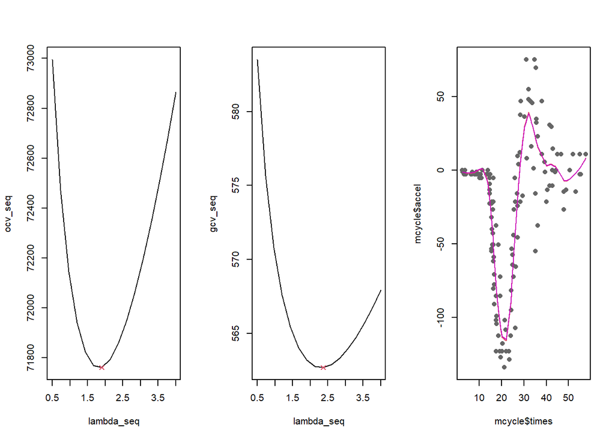

```r
gcv <- function(lambda, y, x,knots){
  n <- length(y)
  modelFit <- preg.fit(y = y, x = x, knots = knots, spar = lambda)
  fval <- fitted(modelFit)[1:n]
  hatValues <- hatvalues(modelFit)[1:n]
  (sum((y-fval)^2)/n)/((1-sum(hatValues)/n)^2)
}
lambda_seq <- seq(.5,4,length.out = 16)
gcv_seq <- ocv_seq <- rep(NA, length(lambda_seq))
for(j in seq_along(lambda_seq)) ocv_seq[j] <- ocv(lambda_seq[j],y = mcycle$accel, x = mcycle$times, knots = seq(0,60,by=2))
for(j in seq_along(lambda_seq)) gcv_seq[j] <- gcv(lambda_seq[j],y = mcycle$accel, x = mcycle$times, knots = seq(0,60,by=2))
par(mfrow = c(1,3), pch = 16)
plot(lambda_seq, ocv_seq, type="l"); points(lambda_seq[which.min(ocv_seq)], min(ocv_seq), pch = 4, col = 2)
plot(lambda_seq, gcv_seq, type="l"); points(lambda_seq[which.min(gcv_seq)], min(gcv_seq), pch = 4, col = 2)
plot(mcycle$times, mcycle$accel, col = "grey40")
lines(mcycle$times, fitted(preg.fit(y =  mcycle$accel, x = mcycle$times, knots = seq(0,60,by=2), spar = lambda_seq[which.min(ocv_seq)]))[1:nrow(mcycle)], col=2, lwd = 1.4)
lines(mcycle$times, fitted(preg.fit(y =  mcycle$accel, x = mcycle$times, knots = seq(0,60,by=2), spar = lambda_seq[which.min(gcv_seq)]))[1:nrow(mcycle)], col=6, lwd = 1.4)
```

```r
rm(lambda_seq, ocv_seq, gcv_seq)
```

Remember that $\boldsymbol{A}$ is the hat matrix such that $\hat{y} = \boldsymbol{A} y$, ie we are working with a linear smoother. Then we have that the so called *equivalent degrees of freedom* (edf) are $edf=tr(\boldsymbol{A})$. This opens the possibility of using methods such as AIC for smoothing parameter selection.

Once $\lambda$ is selected we can estimate our function and carry out our estimation. There is an interesting line of research which aims at quantifying the uncertainty in the estimation due to the fact that $\lambda$ is not actually known but selected.

Another approach is to describe the smoothing problem as a linear mixed model and use (restricted) maximum likelihood for mixed effects models.

Furthermore, we can exploit the fact that penalized regression can be viewed as a Bayesian linear model, in which the prior distribution for the regression parameters is taken to be a Gaussian: when doing so the $\lambda$ parameter is just one more of the parameters for which we need to obtain a posterior distribution. Let’s see how penalized regression corresponds to a Bayesian model with a Gaussian prior on the coefficients.

### Bayesian Linear Models

A Bayesian models with a normal prior on the parameters:

$$\boldsymbol{y} = \boldsymbol{X}
\boldsymbol{\beta} + \boldsymbol{\varepsilon}$$

where $\boldsymbol{\varepsilon}$ is a vector of length $n$ of iid Gaussian error terms with mean 0 and constant known variance $\sigma^2$

We take a prior on the model parameters $\boldsymbol{\beta} \sim MVN(\boldsymbol{0}, \tau I)$ and wish to evaluate the posterior $p(\boldsymbol{\beta}|\boldsymbol{y})$:

$$\begin{align*}
p(\boldsymbol{\beta}|\boldsymbol{y}) & \propto
p(\boldsymbol{y}|\boldsymbol{\beta}) * p(\boldsymbol{\beta}) \\
& \propto \exp\left\{-\frac{(\boldsymbol{y}- \boldsymbol{X}
\boldsymbol{\beta})^T (\boldsymbol{y}- \boldsymbol{X}
\boldsymbol{\beta})}{2 \sigma^2} \right\} \
\exp\left\{-\frac{\boldsymbol{\beta}^T \boldsymbol{\beta}}{2 \tau^2}
\right\} =
\exp\left\{-\frac{1}{2}\left[\frac{1}{\sigma^2}
(\boldsymbol{y}^T \boldsymbol{y} -
2\boldsymbol{\beta}^T\boldsymbol{X}^T \boldsymbol{y} +
\boldsymbol{\beta}^T \boldsymbol{X}^T
\boldsymbol{X} \boldsymbol{\beta}) + \frac{1}{\tau^2}
\boldsymbol{\beta}^T \boldsymbol{\beta} \right] \right\} \\
& \propto
\exp\left\{-\frac{1}{2}\left[\boldsymbol{\beta}^T \left(
\frac{1}{\sigma^2} \boldsymbol{X}^T \boldsymbol{X} + \frac{1}{\tau^2}
\boldsymbol{I} \right) \boldsymbol{\beta} -
2 \frac{1}{\sigma^2} \boldsymbol{\beta}^T \boldsymbol{X}^T
\boldsymbol{y} \right] \right\} \\
& =
\exp\left\{-\frac{1}{2}\left[\boldsymbol{\beta}^T \boldsymbol{A}
\boldsymbol{\beta} -
2 \boldsymbol{b}^T \boldsymbol{\beta} \right] \right\} \ \text{ where
} \boldsymbol{A} = \left( \frac{1}{\sigma^2} \boldsymbol{X}^T
\boldsymbol{X} + \frac{1}{\tau^2} \boldsymbol{I} \right) , \
\boldsymbol{b} = \frac{1}{\sigma^2} \boldsymbol{X}^T \boldsymbol{y} \\
& =
\exp\left\{-\frac{1}{2}\left[(\boldsymbol{\beta}-
\boldsymbol{A}^{-1} \boldsymbol{b})^T \boldsymbol{A}
(\boldsymbol{\beta}- \boldsymbol{A}^{-1} \boldsymbol{b}) -
\boldsymbol{b}^T \boldsymbol{A}^{-1} \boldsymbol{b} \right] \right\}
\propto
\exp\left\{-\frac{1}{2}\left[(\boldsymbol{\beta} -
\boldsymbol{A}^{-1} \boldsymbol{b})^T \boldsymbol{A}
(\boldsymbol{\beta}- \boldsymbol{A}^{-1} \boldsymbol{b}) \right]
\right\}
\end{align*}$$

Thus $p(\boldsymbol{\beta}|\boldsymbol{y})$ is a $N(\boldsymbol{A}^{-1} \boldsymbol{b}, \boldsymbol{A}^{-1})$ and interestingly:
$$E[\boldsymbol{\beta}|\boldsymbol{y}] =
\frac{1}{\sigma^2} \left( \frac{1}{\sigma^2} \boldsymbol{X}^T
\boldsymbol{X} + \frac{1}{\tau^2} \boldsymbol{I} \right)^{-1}
\boldsymbol{X}^T \boldsymbol{y} = \left(\boldsymbol{X}^T
\boldsymbol{X} + \frac{\sigma^2}{\tau^2} \boldsymbol{I} \right)^{-1}
\boldsymbol{X}^T \boldsymbol{y}$$

Thus we see that if we assume a-priori that the coefficients are independent with a common variance we retrieve the ridge regression case. If we were to assume more complex structure in the prior distribution, eg $\boldsymbol{\beta} \sim MVN(\boldsymbol{0}, \tau \boldsymbol{S}^{-})$ we find that the MAP for $\beta$ corresponds to the $\hat{\beta}$ found for penalized regression.

Let’s assess the impact of $\tau$, the prior standard deviation of the $\beta$ coefficients, on the smoothness of the implied functions:

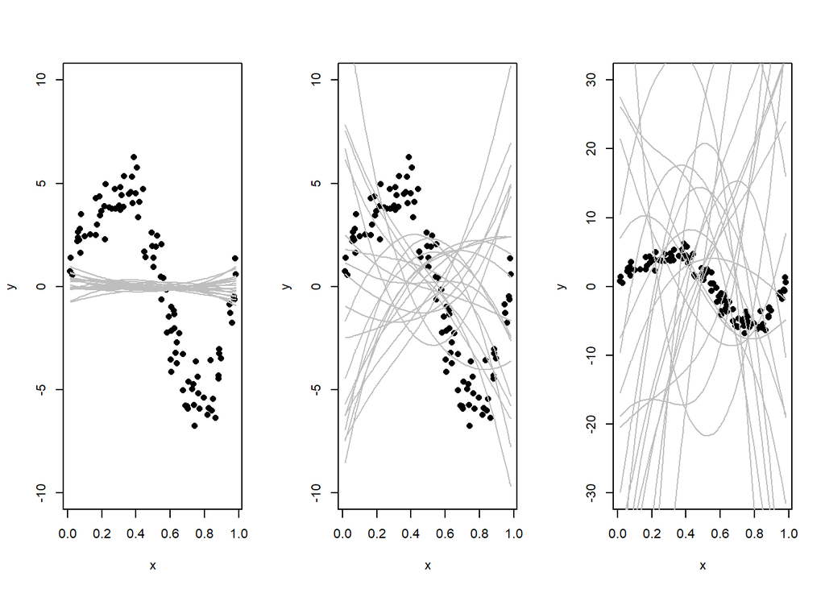

```r
set.seed(454)
## let's generate a vector of xs
n <- 100
x <- sort(runif(n, 0,1))
y <- scale(10*sin(2*pi*x)*x+rnorm(n,0,1), scale = FALSE) # 0 mean
# cubic spline
cSmatrix <- cubSpline(x,seq(0,1,by=0.1))[,-1] # drop the intercept to ensure 0 mean
p <- ncol(cSmatrix)
par(mfrow=c(1,3), pch = 16)
plot(x,y, ylim = c(-10,10))
for(j in 1:20){
  # superflous, but more in line with notation
  # beta_05 <- diag(MASS::mvrnorm(p, rep(0,p), .5*diag(p)))
  beta_05 <- rnorm(p, 0, .5)
  lines(x, scale(cSmatrix %*% (beta_05),scale = FALSE), type = "l",col="grey")
}
plot(x,y, ylim = c(-10,10))
for(j in 1:20){beta_5 <- rnorm(p, 0, 5); lines(x,scale(cSmatrix %*% beta_5,scale = FALSE), type = "l",col="grey")}
plot(x,y, ylim = c(-30,30))
for(j in 1:20){beta_100 <- rnorm(p, 0, 50); lines(x,scale(cSmatrix %*% beta_100,scale = FALSE), type = "l",col="grey")}
```

```r
rm(x,y,j,p,beta_05,beta_5,beta_100,cSmatrix,n)
```

$\tau$ plays a role similar to $\lambda$: this Bayesian interpretation of GAMs open the opportunity of employing the many libraries developed for Bayesian computation to estimate GAM models.

## Generalised addtive models

Till now we have use one covariate but in many situations we believe we will have several predictors influencing the variable of interest. For example, for the `airquality` data, we might want to model the ozone levels as a function of several predictors:

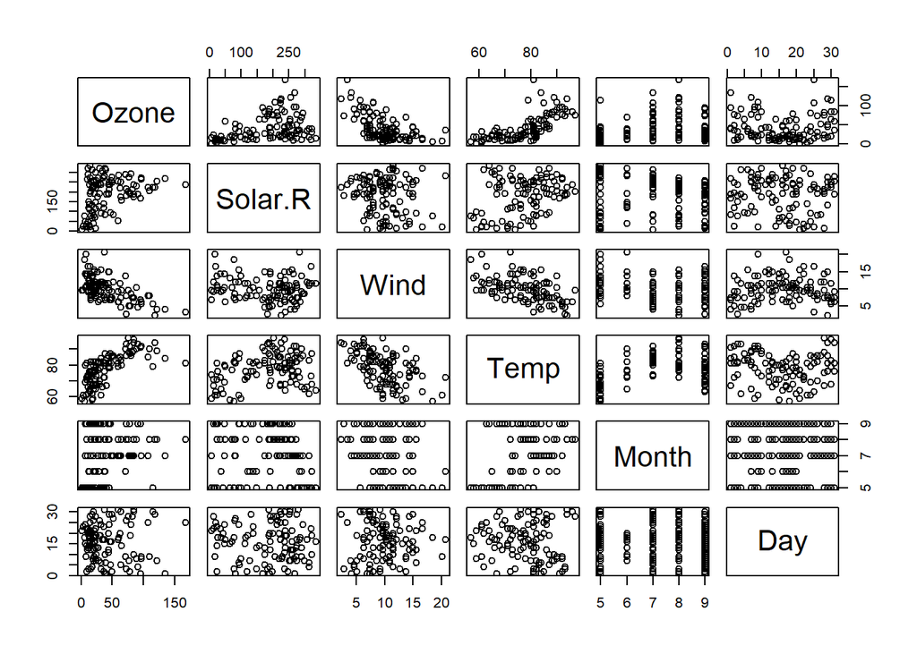

```r
data("airquality")
airquality <- na.omit(airquality) # not best practice...
plot(airquality)
```

i.e. we wish to fit (let’s still assume the gaussian case for the moment):
$$y_i = \beta_0 + f_1(x_{1i}) +
f_2(x_{2i}) + \ldots + f_p(x_{pi}) + \varepsilon_i$$
where each $f_j(x_j)$ can be represented by a linear combination of basis functions, eg. $f_1(x_1) = \sum_{j=1}^{k} b_j(x_1) \beta^{(1)}_j$. We can construct the design matrix for each additive term which can then be defined as a linear combination of the design matrix and the parameter vector, eg $\boldsymbol{f}_1 = \boldsymbol{X_1} \boldsymbol{\beta}^{(1)}$. We also associate a suitable penalty matrix $\boldsymbol{S}_{j}$ to each term.

Notice that the model can only be estimate under some identifiability constraints since we could add any constant to any $f_j(\cdot)$ and this would be reabsorbed in $\beta_0$. In practice then the estimation is carried out under the constraint that each $f_j(\cdot)$ term has a zero mean, eg $\sum_{i=1}^{n} f_1(x_{1i}) = 0$ so $\boldsymbol{1}^\top \boldsymbol{f}_1= 0$ and $\boldsymbol{1}^\top \boldsymbol{X}_1 \boldsymbol{\beta}^{(1)} = 0$ for all $\boldsymbol{\beta}^{(1)}$, which implies $\boldsymbol{1}^\top \boldsymbol{X}_1 = 0$. This is achieved when employing a centered matrix, ie when subtracting to each column its mean:
$$\tilde{\boldsymbol{X}}_1 = \boldsymbol{X}_1 -
\boldsymbol{1} \boldsymbol{1}^\top \boldsymbol{X}_{1}/n.$$
This implies that we only need to estimate $k-1$ parameters rather than $k$: we can simply delete one column out of $\boldsymbol{X}_1$ and the $\boldsymbol{S}_1$ matrix to construct the appropriate $\tilde{\boldsymbol{X}}_1$ and $\tilde{\boldsymbol{S}}_{1}$ matrices

```r
tf.Xc <- function(x,knots, cmx=NULL){
  nk <- length(knots); n <- length(x)
  X <- tf.X(x=x,knots=knots)[,-nk] # remove one column
  D <- diff(diag(nk), differences  = 2)[,-nk]
  # cmx is the column means
  # needed to evaluate function at new locations
  if(is.null(cmx)) cmx <- colMeans(X)
  X <- sweep(X, 2, cmx)
  list(X=X,D=D,cmx=cmx)
}
dim(tf.X(mcycle$times, knots = seq(0,60,length.out=15)))
```

```
## [1] 133  15
```

```r
dim(tf.Xc(mcycle$times, knots = seq(0,60,length.out=15))[["X"]])
```

```
## [1] 133  14
```

```r
mean(tf.X(mcycle$times, knots = seq(0,60,length.out=15)) %*% rnorm(15,1,2))
```

```
## [1] 0.5813992
```

```r
mean(tf.Xc(mcycle$times, knots = seq(0,60,length.out=15))[["X"]] %*% rnorm(14,1,2))
```

```
## [1] 8.508745e-18
```

Since each component has a zero mean the interpretation of $f_j(\cdot)$ will be that of the relative contribution of the covariate to the response.

The model can then be rewritten in general form as:

$$\boldsymbol{y} = \beta_0 +
\boldsymbol{f}_1 + \boldsymbol{f}_2 + \ldots + \boldsymbol{f}_p =
\beta_0 + \tilde{\boldsymbol{X}}_1 \boldsymbol{\beta}^{(1)}+
\tilde{\boldsymbol{X}}_2 \boldsymbol{\beta}^{(2)} + \ldots + +
\tilde{\boldsymbol{X}}_p \boldsymbol{\beta}^{(p)} = \boldsymbol{X}
\boldsymbol{\beta}$$
where $\boldsymbol{X} = [\boldsymbol{1} \ \tilde{\boldsymbol{X}}_1 \cdots \tilde{\boldsymbol{X}}_p]$ and $\boldsymbol{\beta} = [\beta_0 \ \boldsymbol{\beta}^{(1)} \cdots \boldsymbol{\beta}^{(p)}]$. The estimation is carried out using a penalized regression and each component can be penalized accordingly. To facilitate the notation later one, it is easier to express each of the penalties as quadratic penalties for of all parameters, for example:
$$\boldsymbol{P}_1 = \begin{bmatrix}
0 & \boldsymbol{0} & \boldsymbol{0} \\
\boldsymbol{0} & \boldsymbol{\tilde{S}_1} & \boldsymbol{0} \\
\vdots & \vdots & \vdots \\
\boldsymbol{0} & \boldsymbol{0} & \boldsymbol{0} \\
\end{bmatrix}$$

so that
$$\boldsymbol{\beta}^\top
\boldsymbol{P}_1 \boldsymbol{\beta} = \boldsymbol{\beta}^{(1) T}
\tilde{\boldsymbol{S}}_1 \boldsymbol{\beta}^{(1)}$$

Notice that we can have parametric terms such as $f_j(x_j) = \delta x_j$ by simply adding a 0 in the penalty matrix for the rows corresponding to the $j^{th}$ component (hence these approaches are often referred to as semi-parametric regression).

The estimates of $\boldsymbol{\beta}$ are found as the minimizer of:
$$||\boldsymbol{y} -
\boldsymbol{X} \boldsymbol{\beta}||^2 + \sum_{j=1}^{p} \lambda_j
\boldsymbol{\beta}^{(j) T} \boldsymbol{P}_{j} \boldsymbol{\beta}^{T} =
||\boldsymbol{y} - \boldsymbol{X} \boldsymbol{\beta}||^2 +
\boldsymbol{\beta} \boldsymbol{B}^\top \boldsymbol{B}
\boldsymbol{\beta}=
\left\Vert \begin{bmatrix} \boldsymbol{y} \\ \boldsymbol{0}
\end{bmatrix} - \begin{bmatrix} \boldsymbol{X} \\ \boldsymbol{B}
\end{bmatrix} \boldsymbol{\beta} \right\Vert^2$$
where $\boldsymbol{B}$ is a matrix such that $\boldsymbol{B}^\top \boldsymbol{B} = \sum_{j=1}^{p} \lambda_j \boldsymbol{\beta}^{(j) T} \boldsymbol{P}_{j} \boldsymbol{\beta}^{(j)}$, such as, for example

$$\boldsymbol{B} = \begin{bmatrix}
\boldsymbol{0} & \sqrt{\lambda_1} \boldsymbol{D}_1 &
\boldsymbol{0} \\
\vdots & \vdots & \vdots \\
\boldsymbol{0} & \boldsymbol{0} & \sqrt{\lambda_p}
\boldsymbol{D}_p \\
\end{bmatrix}$$

The estimate for $\boldsymbol{\beta}$ is found to be

$$\hat{\boldsymbol{\beta}} =
\left(\boldsymbol{X}^T \boldsymbol{X} + \lambda_1 \boldsymbol{P}_1 +
\ldots+ \lambda_p \boldsymbol{P}_p \right)^{-1} \boldsymbol{X}^T
\boldsymbol{y}.$$

although in practice, for computational stability, we can use the augmented variables approach.

Let’s now see how the ozone levels change as a function of solar radiation and wind. First we construct the design matrix for the whole model:

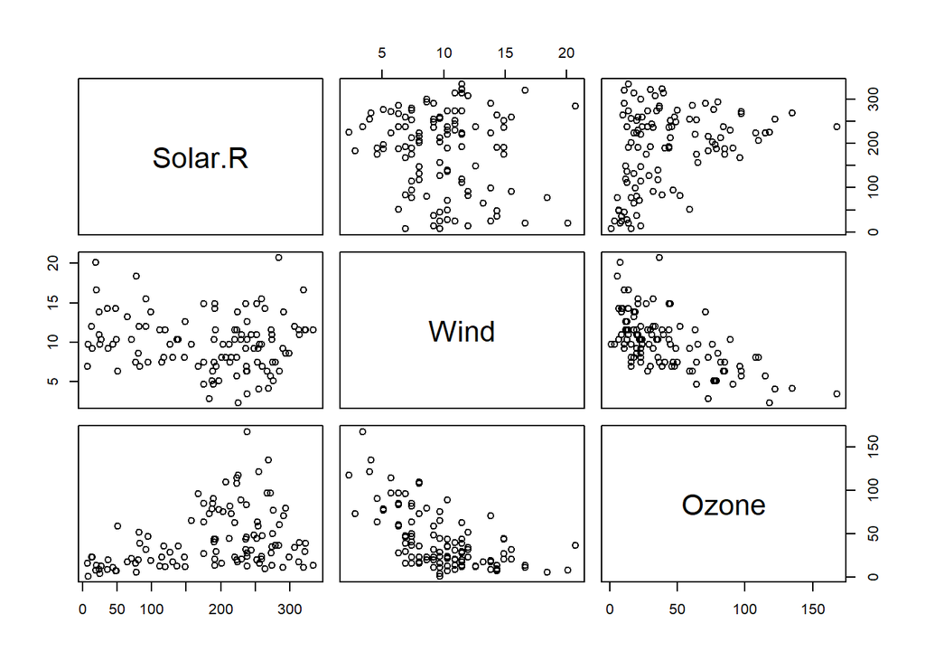

```r
data("airquality")
airquality <- na.omit(airquality)
plot(airquality[,c("Solar.R","Wind","Ozone")])
```

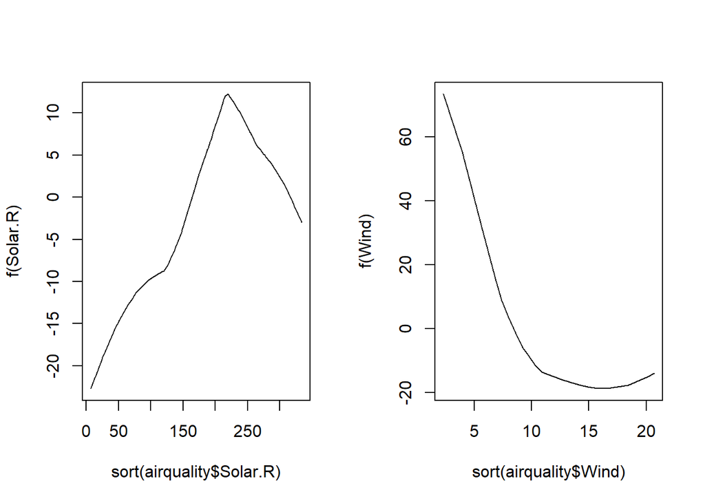

```r
# create basis functions and D matrices for each predictor
Msolar <- tf.Xc(x = airquality$Solar.R, knots = seq(min(airquality$Solar.R), max(airquality$Solar.R), length.out = 15))
Mwind <- tf.Xc(x = airquality$Wind, knots = seq(min(airquality$Wind), max(airquality$Wind), length.out = 12))
# number of coefficients for each predictor
p1 <- ncol(Msolar$X); p2 <- ncol(Mwind$X)
# the overall design matrix
X <- cbind(rep(1,nrow(airquality)), Msolar$X, Mwind$X)
# create the P1 and P2 matrices - they are mostly 0s
Psolar <- matrix(0,ncol=1+p1+p2, nrow = 1+p1+p2); Psolar[2:(1+p1),2:(1+p1)] <-  crossprod(Msolar$D)
Pwind <- matrix(0,ncol=1+p1+p2, nrow = 1+p1+p2); Pwind[(2+p1):(p1+p2+1),(2+p1):(p1+p2+1)] <- crossprod(Mwind$D)
# take arbitrary lambdas
sp1 <- 6; sp2 <- 4
# a first rough estimate with the direct approach
betafit <- (solve(crossprod(X) + sp1 * Psolar + sp2*Pwind) %*% t(X) %*% airquality$Ozone)[,1]
# let's look at the effect of each component
par(mfrow=c(1,2))
plot(sort(airquality$Solar.R),
     X[order((airquality$Solar.R)),2:(1+p1)] %*% betafit[2:(1+p1)],
     type = "l", ylab = "f(Solar.R)") # ylim = c(-20,75)
plot(sort(airquality$Wind),
     X[order((airquality$Wind)),(2+p1):(1+p1+p2)] %*% betafit[(2+p1):(1+p1+p2)],
     type = "l", ylab = "f(Wind)") # ylim = c(-20,75)
```

```r
# constraints on the mean effect of each term
mean(X[order(airquality$Solar.R),2:(1+p1)] %*% betafit[2:(1+p1)])
```

```
## [1] -3.693867e-16
```

```r
mean(X[order(airquality$Wind),(2+p1):(1+p1+p2)] %*% betafit[(2+p1):(1+p1+p2)])
```

```
## [1] -3.003103e-16
```

```r
## for numerical stability it is better to exploit the optimized routines in lm
## use the augmented model
# construct the B matrix
B <- matrix(0,nrow = p1+p2-1, ncol = p1+p2+1);
B[2:(p1),2:(p1+1)] <-  Msolar$D * sqrt(sp1); B[(1+p1):(p1+p2-1),(p1+2):(p1+p2+1)]<-Mwind$D * sqrt(sp2)
# augment y and X
yaugment <- c(airquality$Ozone, rep(0,  p1+p2-1))
Xaugment  <- rbind(X,B)
# use lm to carry out the estimation
coef(lm(yaugment~Xaugment-1))/betafit # same result
```

```
##  Xaugment1  Xaugment2  Xaugment3  Xaugment4  Xaugment5  Xaugment6  Xaugment7
##          1          1          1          1          1          1          1
##  Xaugment8  Xaugment9 Xaugment10 Xaugment11 Xaugment12 Xaugment13 Xaugment14
##          1          1          1          1          1          1          1
## Xaugment15 Xaugment16 Xaugment17 Xaugment18 Xaugment19 Xaugment20 Xaugment21
##          1          1          1          1          1          1          1
## Xaugment22 Xaugment23 Xaugment24 Xaugment25 Xaugment26
##          1          1          1          1          1
```

```r
# how complex is the model we have obtained?
rm(X,B,yaugment,Xaugment,p1,p2,betafit,sp1,sp2,Psolar,Pwind,Mwind,Msolar)
```

Notice that for given $\lambda_1$ and $\lambda_2$ the model is estimated in one unique solution, avoiding backfitting.

### mgcv

Luckily for us we do not need to construct the whole model by hand but we can use packages which are optimized and well tested. The `mgcv` package, developed by [Simon Wood](https://www.maths.ed.ac.uk/~swood34/) is *the* R package to model generalised additive models, although later I list a number of other packages which are also very relevant. Let’s see `mgcv` in practice:

```r
suppressPackageStartupMessages(library(mgcv))
fit_aq <- gam(Ozone~s(Solar.R)+s(Wind), data = airquality) # s() to obtain smooth terms
# similar in structure to a summary.lm
summary(fit_aq)
```

```
##
## Family: gaussian
## Link function: identity
##
## Formula:
## Ozone ~ s(Solar.R) + s(Wind)
##
## Parametric coefficients:
##             Estimate Std. Error t value Pr(>|t|)
## (Intercept)   42.099      2.033    20.7   <2e-16 ***
## ---
## Signif. codes:  0 '***' 0.001 '**' 0.01 '*' 0.05 '.' 0.1 ' ' 1
##
## Approximate significance of smooth terms:
##              edf Ref.df      F  p-value
## s(Solar.R) 2.377  2.978  7.377 0.000159 ***
## s(Wind)    2.886  3.629 27.408  < 2e-16 ***
## ---
## Signif. codes:  0 '***' 0.001 '**' 0.01 '*' 0.05 '.' 0.1 ' ' 1
##
## R-sq.(adj) =  0.586   Deviance explained = 60.5%
## GCV = 486.33  Scale est. = 458.89    n = 111
```

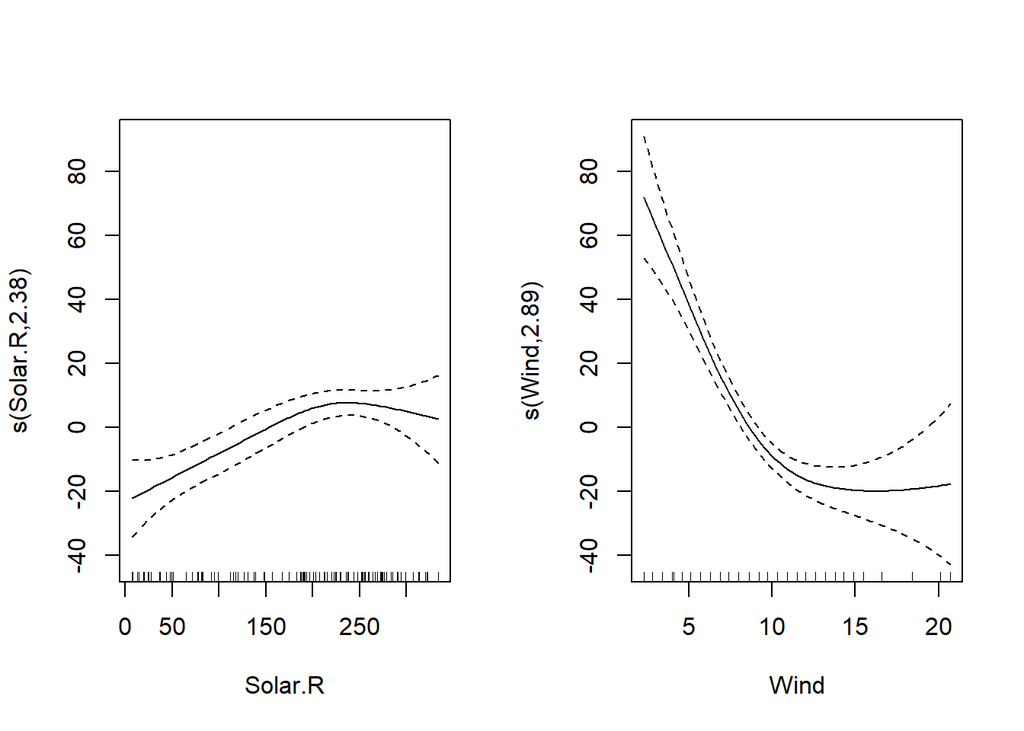

```r
par(mfrow=c(1,2))
plot(fit_aq) # by default mgcv plots 95% confidence intervals
```

Reading the help file of `?gam` is very instructive. We see that by default the data is assumed to follow a Gaussian distribution, but a number of families are allowed. The estimation for distributions which are not the Gaussian typically is based on using the log-likelihood rather than the squared residual as the goodness of fit measure in the penalized regression. Similarly to what happens in GLM, computations need to be adapted, but solutions can be found.

The `method` option controls the method used to choose the smoothing parameter: the default is “GCV.Cp” (ie a GCV with appropriate correction for the scale when this is unknown), but we see many other options: “REML” is based on the mixed model representation of GAMs and has been shown to perform better than GCV in practice (Reiss and Ogden, 2009, JRSSB, doi:10.1111/j.1467-9868.2008.00695.x).

In our manual estimation of GAM models we have mostly used the tent function to fit out model: tent function are composed by polynomials of order 1 and hence can only estimate functions with moderate flexibility. In practice we typically used cubic regression splines, which can estimate function with continuous second order derivatives at the knots or use thin plate regression splines, a low-rank approximation of thin plate splines. Indeed thin-plate regression splines are the default basis for the `mgcv` package - as we can learn looking at `?s`.

We can deviate from the defaults and use, for example, cubic regression splines with a larger number of knots and REML for smoothing parameter selection:

```r
fit2_aq <- gam(Ozone~s(Solar.R,k=15, bs = "cr")+s(Wind, k=12, bs = "cr"), data = airquality, method = "REML")
# similar in structure to a summary.lm
summary(fit2_aq)
```

```
##
## Family: gaussian
## Link function: identity
##
## Formula:
## Ozone ~ s(Solar.R, k = 15, bs = "cr") + s(Wind, k = 12, bs = "cr")
##
## Parametric coefficients:
##             Estimate Std. Error t value Pr(>|t|)
## (Intercept)   42.099      2.031   20.73   <2e-16 ***
## ---
## Signif. codes:  0 '***' 0.001 '**' 0.01 '*' 0.05 '.' 0.1 ' ' 1
##
## Approximate significance of smooth terms:
##              edf Ref.df      F  p-value
## s(Solar.R) 2.429  3.045  7.151 0.000194 ***
## s(Wind)    3.520  4.383 23.248  < 2e-16 ***
## ---
## Signif. codes:  0 '***' 0.001 '**' 0.01 '*' 0.05 '.' 0.1 ' ' 1
##
## R-sq.(adj) =  0.587   Deviance explained = 60.9%
## -REML = 491.71  Scale est. = 457.81    n = 111
```

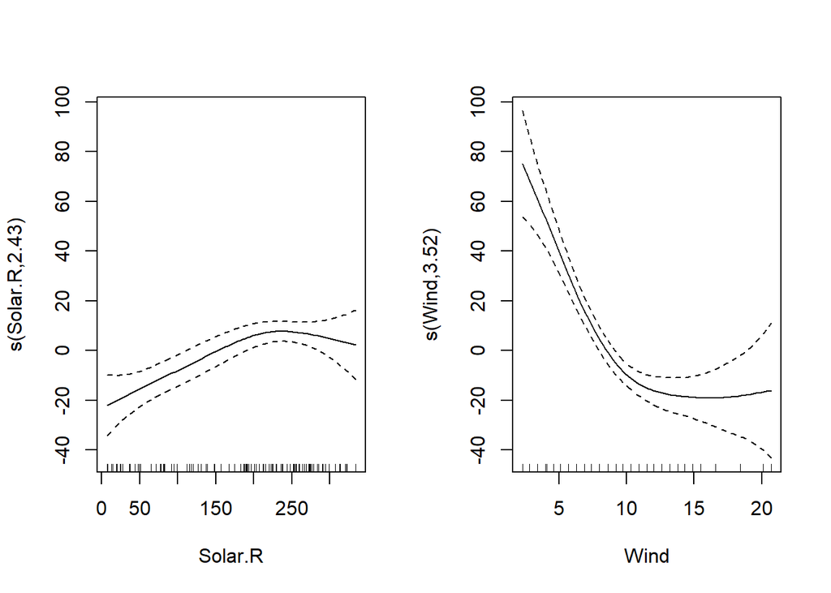

```r
par(mfrow=c(1,2))
plot(fit2_aq)
```

```r
length(coef(fit_aq)); length(coef(fit2_aq))
```

```
## [1] 19
```

```
## [1] 26
```

```r
fit_aq$df.residual; fit2_aq$df.residual
```

```
## [1] 104.7365
```

```
## [1] 104.0505
```

Even if we have estimated a much high number of coefficients in the second model we end up using a similar number of equivalent degrees of freedom: the automatic smoothing parameter selection results in similar estimated function.

Some small plots to comment on interesting aspects of the fit:

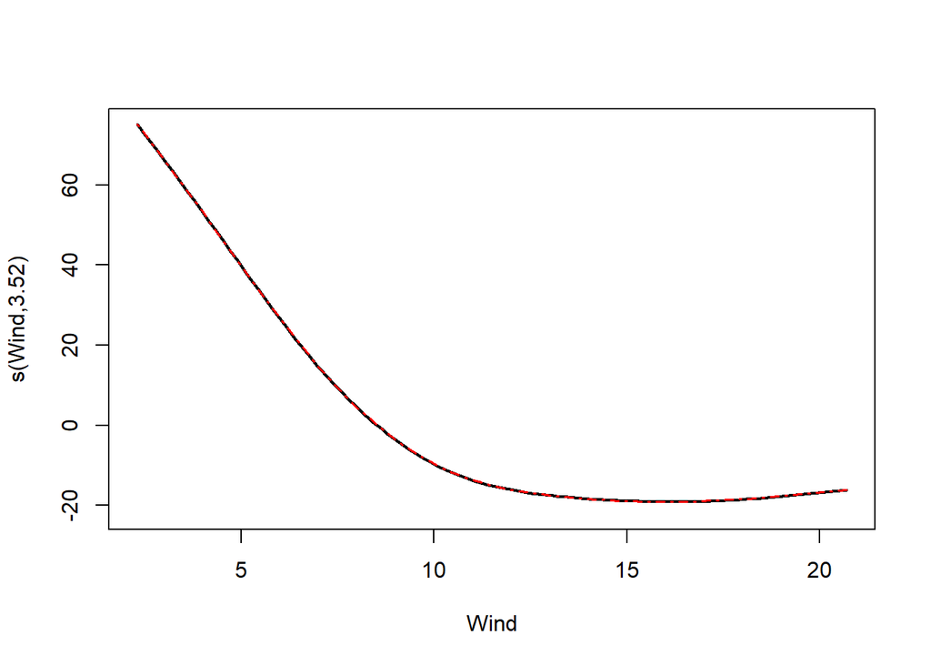

```r
# after all - we are actually fitting a linear model
# let's see what happens for the Wind variable
X <- model.matrix(fit2_aq)[order(airquality$Wind),]
plot(fit2_aq, select = 2, se = FALSE, rug = FALSE, lwd = 2)
lines(sort(airquality$Wind),
      X[,grep("Wind",colnames(X))] %*% coef(fit2_aq)[grep("Wind",colnames(X))],
      lty = 4, col = "red",lwd = 1.8)
```

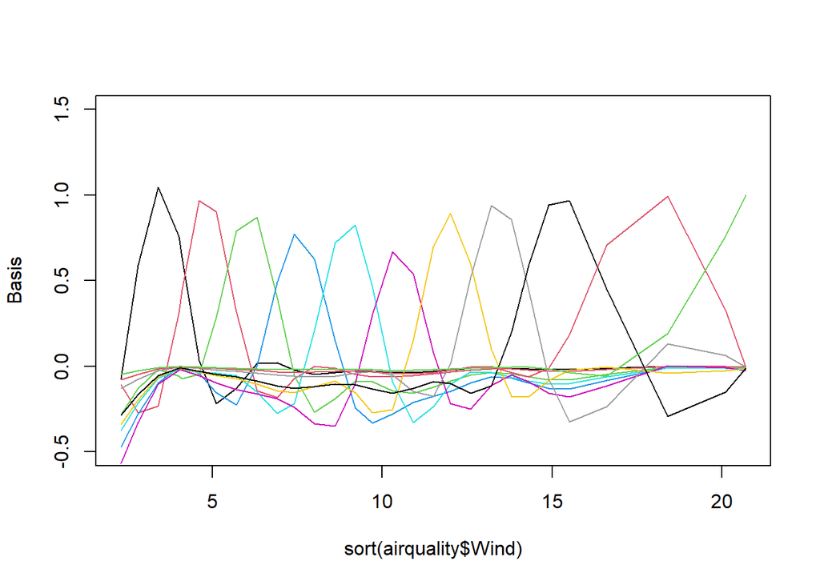

```r
# Let's look at the columns of the model matrix -
plot(sort(airquality$Wind),
      X[,grep("Wind",colnames(X))][,1], type="l", ylim = c(-.5,1.5),ylab="Basis")
for(j in 2:length(grep("Wind",colnames(X)))) lines(sort(airquality$Wind),X[,grep("Wind",colnames(X))][,j],col=j)
```

```r
rm(X,j)
```

### Some useful basis

We now explore some useful basis functions available in GAM which allow for the estimation of fairly complex models in the same framework of penalized regression used in GAM smoothing: we start with an example of varying coefficient models (taken from the excellent book *Bayesian and Frequentist Regression Methods* by Jon Wakefield).

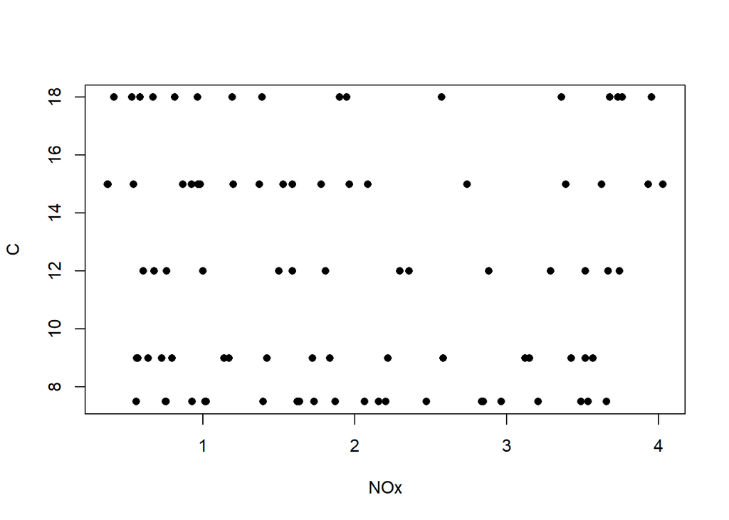

```r
data(ethanol, package = "SemiPar")
ethanol <- ethanol[order(ethanol$E),]
# help(ethanol)
with(ethanol, plot(NOx,C, pch = 16))
```

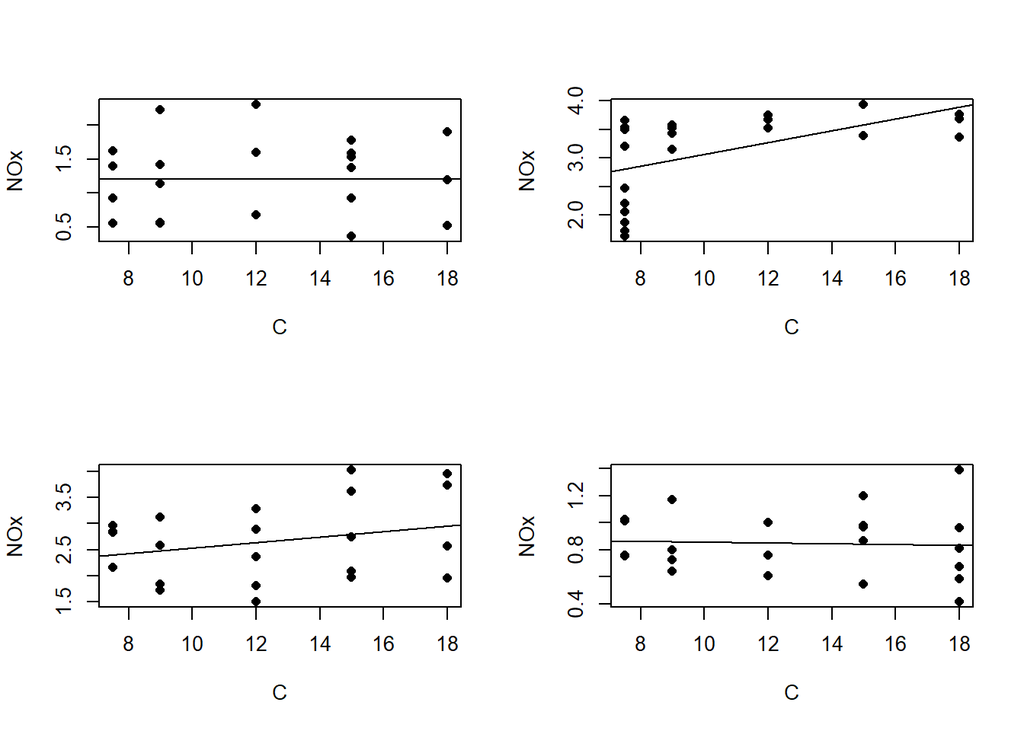

```r
par(mfrow=c(2,2), pch = 16)
with(ethanol[ 1:22,], plot(NOx ~ C)); with(ethanol[ 1:22,], abline(lm(NOx ~ C)))
with(ethanol[23:44,], plot(NOx ~ C)); with(ethanol[23:44,], abline(lm(NOx ~ C)))
with(ethanol[45:66,], plot(NOx ~ C)); with(ethanol[45:66,], abline(lm(NOx ~ C)))
with(ethanol[67:88,], plot(NOx ~ C)); with(ethanol[67:88,], abline(lm(NOx ~ C)))
```

```r
# effect of NOx on C is different for different levels of E
```

In `mgcv` this can be achieved using the `by` argument in `s`:

```r
fit_eth <- gam(NOx~s(E,bs="cr")+s(E,by=C,bs="cr"), data = ethanol)
summary(fit_eth)
```

```
##
## Family: gaussian
## Link function: identity
##
## Formula:
## NOx ~ s(E, bs = "cr") + s(E, by = C, bs = "cr")
##
## Parametric coefficients:
##             Estimate Std. Error t value Pr(>|t|)
## (Intercept)  1.29357    0.06526   19.82   <2e-16 ***
## ---
## Signif. codes:  0 '***' 0.001 '**' 0.01 '*' 0.05 '.' 0.1 ' ' 1
##
## Approximate significance of smooth terms:
##          edf Ref.df     F p-value
## s(E)   6.397  7.295 38.96  <2e-16 ***
## s(E):C 4.672  5.360 35.64  <2e-16 ***
## ---
## Signif. codes:  0 '***' 0.001 '**' 0.01 '*' 0.05 '.' 0.1 ' ' 1
##
## R-sq.(adj) =  0.976   Deviance explained = 97.9%
## GCV = 0.035978  Scale est. = 0.031044  n = 88
```

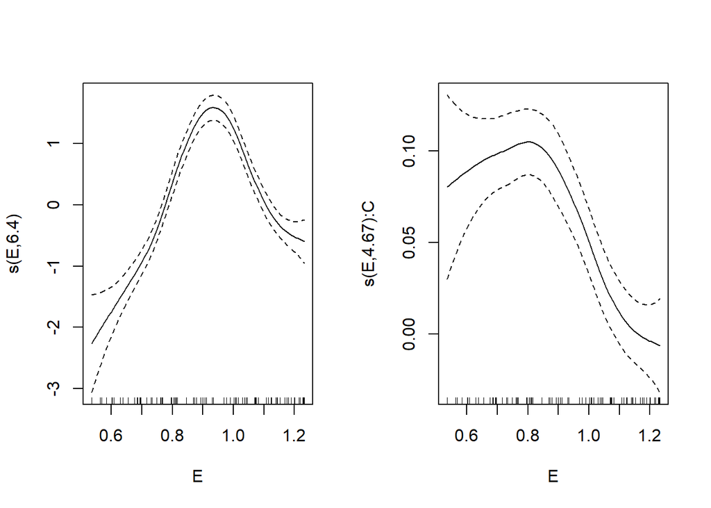

```r
# effective degrees of freedom of 6.4 and 4.7 on the intercept and slope smooths
par(mfrow=c(1,2))
plot(fit_eth, scale = 0)
```

```r
# how are values fitted values
predict(fit_eth, newdata = data.frame(E=1.2,C=c(10,16)), type = "terms")
```

```
##         s(E)      s(E):C
## 1 -0.5235571 -0.03924128
## 2 -0.5235571 -0.06278604
## attr(,"constant")
## (Intercept)
##    1.293572
```

```r
predict(fit_eth, newdata = data.frame(E=1.2,C=c(10,16)))
```

```
##         1         2
## 0.7307735 0.7072287
```

```r
predict(fit_eth, newdata = data.frame(E=0.6,C=c(10,16)), type = "terms")
```

```
##        s(E)    s(E):C
## 1 -1.737118 0.8892389
## 2 -1.737118 1.4227822
## attr(,"constant")
## (Intercept)
##    1.293572
```

```r
predict(fit_eth, newdata = data.frame(E=0.6,C=c(10,16)))
```

```
##         1         2
## 0.4456929 0.9792363
```

```r
# notice we have the usual functions we expect for linear model
```

Let’s look at the basis function for each of the terms:

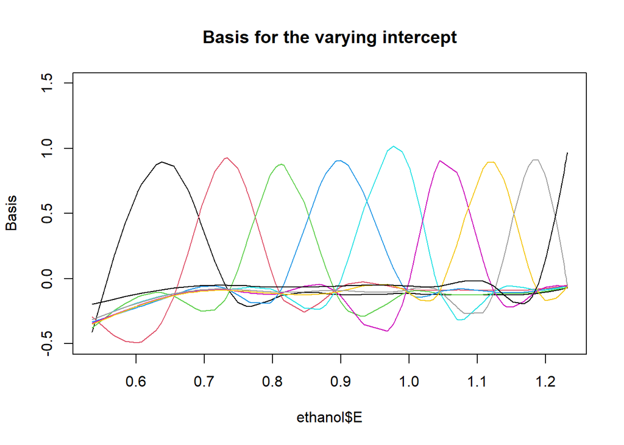

```r
# Let's look at the columns of the model matrix -
X <- model.matrix(fit_eth)
#colnames(X)
# basis used to estimate the intercept
plot(ethanol$E,
      X[,grep("E)[.]",colnames(X))][,1], type="l", ylim = c(-.5,1.5),ylab="Basis")
title(main="Basis for the varying intercept")
for(j in 2:length(grep("E)[.]",colnames(X)))) lines(ethanol$E,X[,grep("E)[.]",colnames(X))][,j],col=j)
```

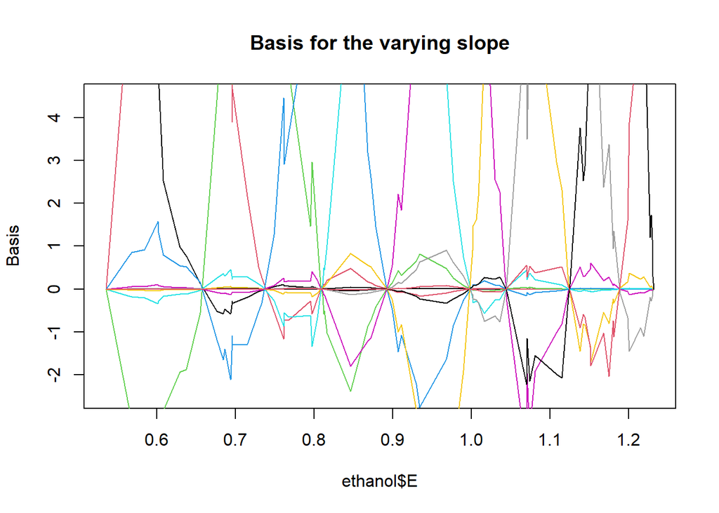

```r
# basis for the slope
plot(ethanol$E,
      X[,grep("E)[:]",colnames(X))][,1], type="l", ylim = c(-2.5,4.5),ylab="Basis")
title(main="Basis for the varying slope")
for(j in 2:length(grep("E)[:]",colnames(X)))) lines(ethanol$E,X[,grep("E)[:]",colnames(X))][,j],col=j)
```

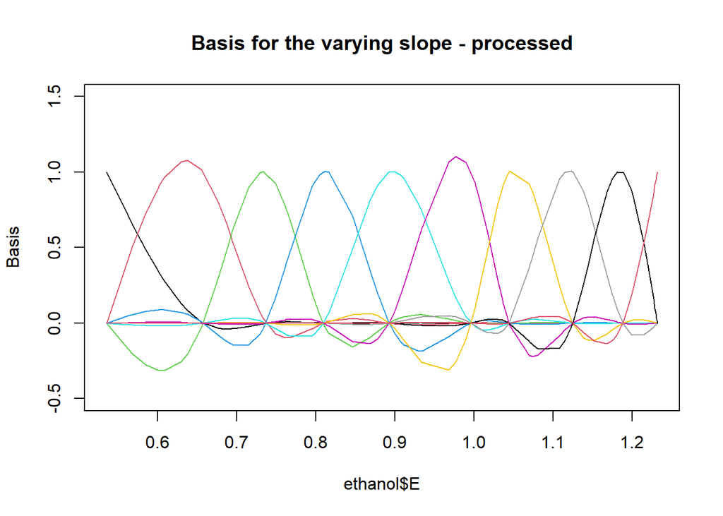

```r
# something looks off
plot(ethanol$E,
      X[,grep("E)[:]",colnames(X))][,1]/ethanol$C, type="l", ylim = c(-.5,1.5),ylab="Basis")
title(main="Basis for the varying slope - processed")
for(j in 2:length(grep("E)[:]",colnames(X)))) lines(ethanol$E,X[,grep("E)[:]",colnames(X))][,j]/ethanol$C,col=j)
```

```r
# back to normal - the actual basis is obtained by multiplying the original basis and the _by_ predictor
rm(X,j)
```

The varying coefficient model is one of the simplest models which showcases one incredible advantage of the GAM-style of fitting based on penalized likelihood: as long as we can express the relationship between the (link-transformed) response and the predictor(s) as a linear combination $\boldsymbol{X} \boldsymbol{\beta}$ subject to some constraints $\boldsymbol{\beta}^\top \boldsymbol{S} \boldsymbol{\beta}$ we can use the GAM-style machinery to estimate the model (and evaluate the smoothness/regularization on the estimated function). This includes an incredibly vast class of model, including geo-additive models, cluster-specific random effects, multi-variate tensor products of several predictors… Due to the richness of the type of relationship between the predictors and the response, Fahrmeir et al, among others use the name Structured Additive Regression (STAR) Models. Notice though that event when multi-variable tensor products can be employed the “restriction” of the model being additive can not fully be relaxed (yet!).

In `mgcv` several types of predictors can be included, an overview can be seen in `?smooth.terms`.

### The G of GAMs

Until now we have analysed data assuming a Gaussian distribution: this is hardly a general assumption, real data come in all forms, for example they might be discrete and/or skewed. `mgcv` allows for different distributions to be estimated: this can be specified via the `family` option. Let’s look for example at the precipitation data from the German climate data: precipitation is by definition skewed and can only be positive, we could employ a Gamma distribution. Looking at the data though it is clear that something radically change in the data recording procedure around 1878: we only focus on the record after that year:

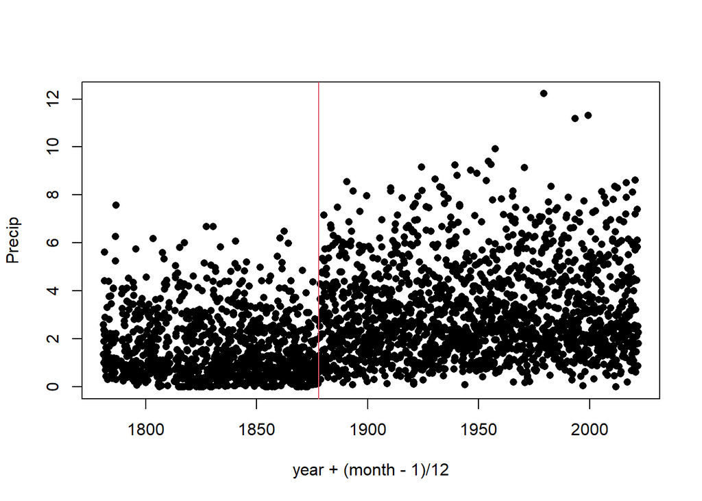

```r
with(climDat, plot(year+(month-1)/12, Precip, pch = 16))
abline(v=1878, col = 2)
```

(don’t forget that careful checks on the data are still a key element even when you can use advanced modelling techniques).

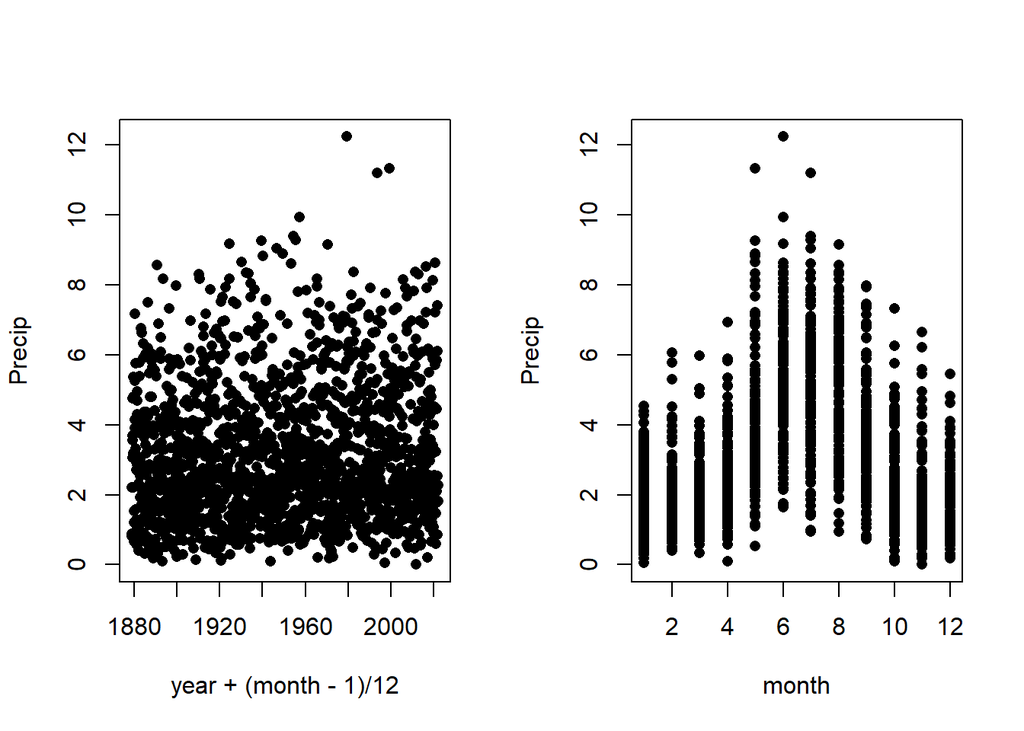

```r
subclim <- climDat[climDat$year > 1878,]
par(mfrow=c(1,2))
with(subclim, plot(year+(month-1)/12, Precip, pch = 16))
with(subclim, plot(month, Precip, pch = 16)) #  strong seasonal component
```

```r
# let's fit a GAM
fit_precip <- gam(Precip ~ s(year, k=20)+s(month, k = 12), family = "Gamma", data = subclim)
summary(fit_precip)
```

```
##
## Family: Gamma
## Link function: inverse
##
## Formula:
## Precip ~ s(year, k = 20) + s(month, k = 12)
##
## Parametric coefficients:
##             Estimate Std. Error t value Pr(>|t|)
## (Intercept) 0.376803   0.004657   80.91   <2e-16 ***
## ---
## Signif. codes:  0 '***' 0.001 '**' 0.01 '*' 0.05 '.' 0.1 ' ' 1
##
## Approximate significance of smooth terms:
##            edf Ref.df       F p-value
## s(year)  1.547  1.911   7.992  0.0014 **
## s(month) 7.848  9.248 113.996  <2e-16 ***
## ---
## Signif. codes:  0 '***' 0.001 '**' 0.01 '*' 0.05 '.' 0.1 ' ' 1
##
## R-sq.(adj) =   0.44   Deviance explained = 38.3%
## GCV = 0.26917  Scale est. = 0.2328    n = 1716
```

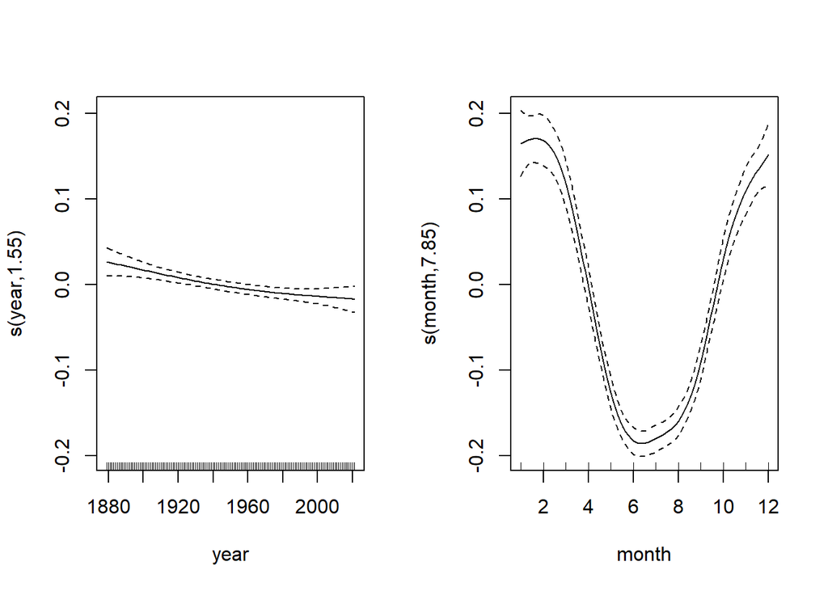

```r
plot(fit_precip) # the term plots
```

We see that the seasonal variation dominates the signal, a small trend in time is visible, but it is not a very noticeable signal (compare it to the one we can obtain for the temperature data, which can be assumed to be normally distributed).

We have included month as if it was a continuous variable, but in reality we only have 12 possible values and the variable is not really continuous, but rather a cyclical, since 1 comes after 12. We can enforce the basis used to model a smooth term to take the same value in the last and first knot, and if we also enforce that the first and last parameter for the smooth term are equal, we obtain that the value at the first and last covariate value are the same: this can avoid awkward large discontinuities where we would actually want the function to be continuous. This can be obtained with cyclic splines, and using the `bs="cc"` option in `s`:

```r
par(mfrow=c(1,2))
# let's fit a GAM
fit2_precip <- gam(Precip ~ s(year, k=20)+s(month, bs = "cc", k = 12),
                   family = "Gamma", data = subclim)
# one less parameter to estimate
#dim(model.matrix(fit_precip)); dim(model.matrix(fit2_precip))
summary(fit2_precip)
```

```
##
## Family: Gamma
## Link function: inverse
##
## Formula:
## Precip ~ s(year, k = 20) + s(month, bs = "cc", k = 12)
##
## Parametric coefficients:
##             Estimate Std. Error t value Pr(>|t|)
## (Intercept) 0.376450   0.004644   81.05   <2e-16 ***
## ---
## Signif. codes:  0 '***' 0.001 '**' 0.01 '*' 0.05 '.' 0.1 ' ' 1
##
## Approximate significance of smooth terms:
##            edf Ref.df       F p-value
## s(year)  1.548  1.912   7.999 0.00139 **
## s(month) 6.206 10.000 105.477 < 2e-16 ***
## ---
## Signif. codes:  0 '***' 0.001 '**' 0.01 '*' 0.05 '.' 0.1 ' ' 1
##
## R-sq.(adj) =  0.441   Deviance explained = 38.3%
## GCV = 0.26876  Scale est. = 0.23259   n = 1716
```

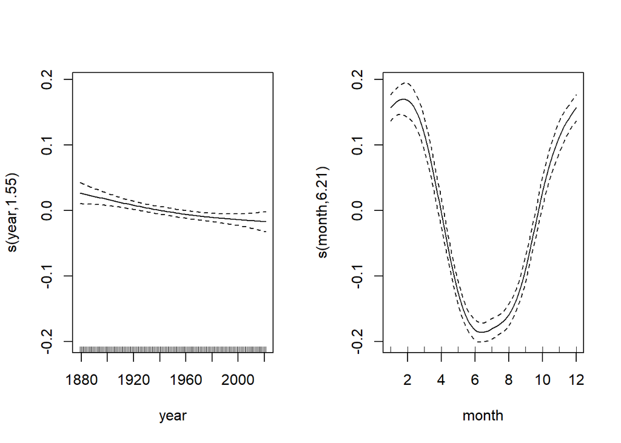

```r
plot(fit2_precip)
```

The fit is not radically different. Let’s compare the first 36 fitted values:

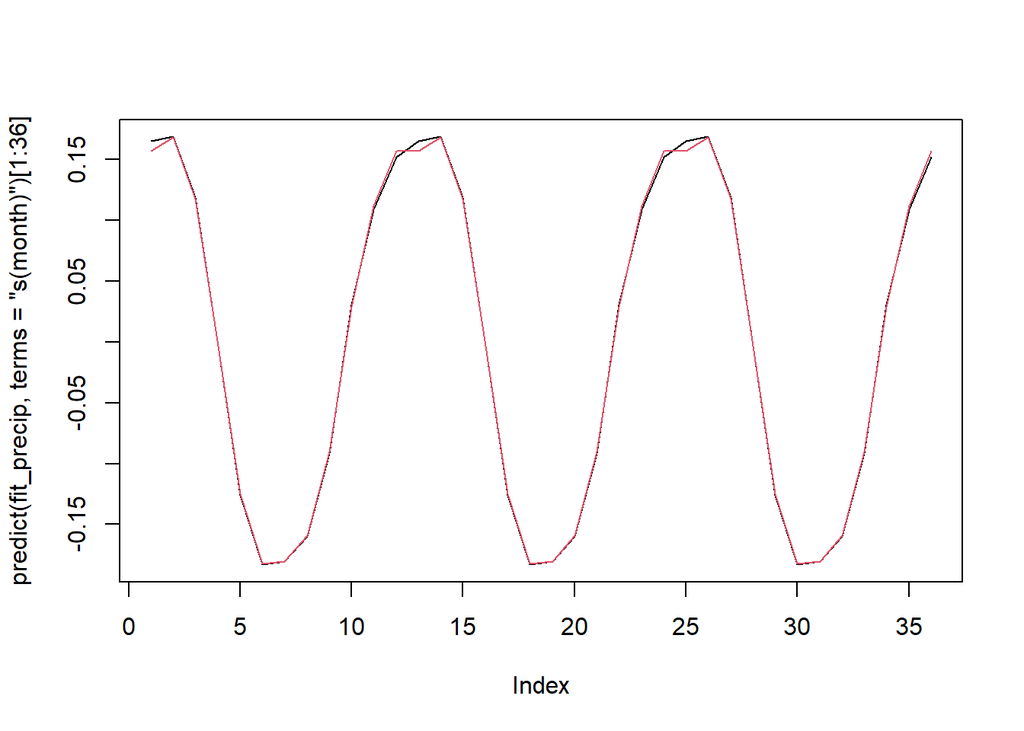

```r
plot(predict(fit_precip, terms = "s(month)")[1:36], type = "l")
lines(predict(fit2_precip, terms = "s(month)")[1:36], type = "l", col = 2)
```

```r
predict(fit_precip, terms = "s(month)")[c(12,13,24,25)]
```

```
##      1128      1129      1140      1141
## 0.1518456 0.1650545 0.1518456 0.1650545
```

```r
predict(fit2_precip, terms = "s(month)")[c(12,13,24,25)]
```

```
##      1128      1129      1140      1141
## 0.1568644 0.1568644 0.1568644 0.1568644
```

We notice that December and January are forced to have the same value. For this application this might be somewhat restrictive, but when data is available at a finer scale (minute of the day, or angles around a circle) there could be some benefit in enforcing the end and the beginning of the record to have matching values.

From the plots and the commands used above we notice that `mgcv::gam` operates in a way similar to `glm`: the actual estimation is carried out in the link-transformed space and the inverse link needs to be employed when we wish to retrieve estimates of the distribution’s expected value:

```r
1/predict(fit_precip)[1:10]
```

```
##     1117     1118     1119     1120     1121     1122     1123     1124
## 1.759177 1.748371 1.915237 2.498842 3.602688 4.536797 4.480013 4.102737
##     1125     1126
## 3.208665 2.305211
```

```r
fitted(fit_precip)[1:10]
```

```
##  [1] 1.759177 1.748371 1.915237 2.498842 3.602688 4.536797 4.480013 4.102737
##  [9] 3.208665 2.305211
```

A list of distributions available for `mgcv` (which are well beyond the exponential family) can be retrieved at `?family.mgcv`. Some of these are indicated as location-scale: for these distributions we allow parameters other than the location to also depend on the predictor, thus constructing generalized additive models for location, scale and shape (GAMLSS).